# Methods for Data Science: Coursework 2

```python
import numpy as np
import pandas as pd
import matplotlib.pyplot as plt

from scipy.linalg import eigh
from scipy.sparse import linalg
from scipy.stats import multivariate_normal
```

## Task 1: Neural Networks, Dimensionality Reduction and Mixture Models (65 marks)

### 1.0 Data

We first load the training data and visualise it.

```python
# Load the data.
mnist_train = pd.read_csv('mnist_train.csv')
mnist_test = pd.read_csv('mnist_test.csv')
mnist_train_noisy = pd.read_csv('MNIST_train_noisy.txt', sep=" ", header=None)
mnist_test_noisy = pd.read_csv('MNIST_test_noisy.txt', sep=" ", header=None)
```

```python
# Store the shape of the images.
mnist_image_shape = (28, 28)
```

```python
# Visualise the first 5 rows.
mnist_train.head(5)
```

|  | label | 1x1 | 1x2 | 1x3 | 1x4 | 1x5 | 1x6 | 1x7 | 1x8 | 1x9 | ... | 28x19 | 28x20 | 28x21 | 28x22 | 28x23 | 28x24 | 28x25 | 28x26 | 28x27 | 28x28 |
| --- | --- | --- | --- | --- | --- | --- | --- | --- | --- | --- | --- | --- | --- | --- | --- | --- | --- | --- | --- | --- | --- |
| 0 | 4 | 0 | 0 | 0 | 0 | 0 | 0 | 0 | 0 | 0 | ... | 0 | 0 | 0 | 0 | 0 | 0 | 0 | 0 | 0 | 0 |
| 1 | 9 | 0 | 0 | 0 | 0 | 0 | 0 | 0 | 0 | 0 | ... | 0 | 0 | 0 | 0 | 0 | 0 | 0 | 0 | 0 | 0 |
| 2 | 7 | 0 | 0 | 0 | 0 | 0 | 0 | 0 | 0 | 0 | ... | 0 | 0 | 0 | 0 | 0 | 0 | 0 | 0 | 0 | 0 |
| 3 | 8 | 0 | 0 | 0 | 0 | 0 | 0 | 0 | 0 | 0 | ... | 0 | 0 | 0 | 0 | 0 | 0 | 0 | 0 | 0 | 0 |
| 4 | 2 | 0 | 0 | 0 | 0 | 0 | 0 | 0 | 0 | 0 | ... | 0 | 0 | 0 | 0 | 0 | 0 | 0 | 0 | 0 | 0 |

5 rows × 785 columns

```python
# Visualise the first 5 rows.
mnist_train_noisy.head(5)
```

|  | 0 | 1 | 2 | 3 | 4 | 5 | 6 | 7 | 8 | 9 | ... | 774 | 775 | 776 | 777 | 778 | 779 | 780 | 781 | 782 | 783 |
| --- | --- | --- | --- | --- | --- | --- | --- | --- | --- | --- | --- | --- | --- | --- | --- | --- | --- | --- | --- | --- | --- |
| 0 | 14.6928 | 41.54430 | 0.650907 | 1.840060 | -13.7111 | 2.70121 | 6.83062 | 2.09018 | 13.268500 | -18.1447 | ... | 0.258495 | 2.873340 | -25.03930 | 1.99615 | 16.16070 | -5.719610 | 50.55980 | 21.3238 | -12.2810 | -14.281200 |
| 1 | 15.3966 | 3.48577 | -9.859870 | 0.118088 | -20.4242 | 7.05606 | -7.52257 | -10.05210 | 36.961100 | 15.2378 | ... | -49.228200 | -0.718321 | -8.45148 | 11.21700 | 11.39290 | -45.847100 | 15.66640 | -23.1307 | -11.7599 | 23.594000 |
| 2 | -11.0810 | -26.95600 | 35.461200 | 17.933200 | 27.0783 | 10.06230 | -1.39500 | -9.70152 | -0.209274 | -25.9756 | ... | 25.887800 | -3.327740 | -8.33229 | -9.38559 | -2.29055 | -15.951000 | -17.68880 | 37.2149 | -39.6784 | 1.759430 |
| 3 | -14.0739 | 8.25860 | -19.878500 | -34.264400 | 17.9438 | 2.41847 | -20.42540 | 61.76750 | -9.236050 | 28.4589 | ... | 19.365200 | 1.560740 | -13.91450 | -40.45090 | 7.99698 | 11.741300 | 2.23981 | 37.5290 | 36.7471 | -0.942664 |
| 4 | -17.5225 | -8.16958 | 3.151930 | -0.275071 | -35.8109 | 20.09230 | 22.93350 | 7.17066 | -2.912430 | 27.5866 | ... | -18.768500 | 14.614500 | -23.66130 | 9.91770 | -17.43010 | -0.103124 | 10.03820 | -29.4632 | 21.2691 | -14.285800 |

5 rows × 784 columns

We convert the data to a `numpy.ndarray`.

```python
# Convert the data to numpy array.
train_data = mnist_train.drop(columns=['label']).to_numpy()
train_labels = mnist_train['label'].to_numpy()
noisy_train_data = mnist_train_noisy.to_numpy()
test_data = mnist_test.drop(columns=['label']).to_numpy()
noisy_test_data = mnist_test_noisy.to_numpy()

# Print the shape of the data.
print("Shape of traning data:", train_data.shape)
print("Shape of noisy traning data:", noisy_train_data.shape)
print("Shape of test data:", test_data.shape)
print("Shape of noisy test data:", noisy_test_data.shape)
```

```
Shape of traning data: (6000, 784)
Shape of noisy traning data: (6000, 784)
Shape of test data: (1000, 784)
Shape of noisy test data: (1000, 784)
```

We apply one-hot enconding to the labels.

```python
# Perform one-hot encoding on the labels.
y_train = pd.get_dummies(mnist_train['label'])
y_train.head(5)
```

|  | 0 | 1 | 2 | 3 | 4 | 5 | 6 | 7 | 8 | 9 |
| --- | --- | --- | --- | --- | --- | --- | --- | --- | --- | --- |
| 0 | 0 | 0 | 0 | 0 | 1 | 0 | 0 | 0 | 0 | 0 |
| 1 | 0 | 0 | 0 | 0 | 0 | 0 | 0 | 0 | 0 | 1 |
| 2 | 0 | 0 | 0 | 0 | 0 | 0 | 0 | 1 | 0 | 0 |
| 3 | 0 | 0 | 0 | 0 | 0 | 0 | 0 | 0 | 1 | 0 |
| 4 | 0 | 0 | 1 | 0 | 0 | 0 | 0 | 0 | 0 | 0 |

```python
# Convert the data to numpy arrays.
X_train = train_data
y_train = y_train.to_numpy()

# Normalize the data.
X_train = X_train / 255.0

# Print the shapes of the arrays.
print(f"X_train shape: {X_train.shape}")
print(f"y_train shape: {y_train.shape}")
```

```
X_train shape: (6000, 784)
y_train shape: (6000, 10)
```

We do the same for the test data.

```python
# Perform one-hot encoding on the labels.
y_test = pd.get_dummies(mnist_test['label'])
y_test.head(5)
```

|  | 0 | 1 | 2 | 3 | 4 | 5 | 6 | 7 | 8 | 9 |
| --- | --- | --- | --- | --- | --- | --- | --- | --- | --- | --- |
| 0 | 1 | 0 | 0 | 0 | 0 | 0 | 0 | 0 | 0 | 0 |
| 1 | 0 | 0 | 0 | 0 | 0 | 0 | 1 | 0 | 0 | 0 |
| 2 | 0 | 0 | 0 | 1 | 0 | 0 | 0 | 0 | 0 | 0 |
| 3 | 0 | 1 | 0 | 0 | 0 | 0 | 0 | 0 | 0 | 0 |
| 4 | 0 | 0 | 0 | 0 | 0 | 0 | 0 | 1 | 0 | 0 |

```python
# Convert the data to numpy arrays.
X_test = test_data
y_test = y_test.to_numpy()

# Normalize the data.
X_test = X_test / 255.0

# Print the shapes of the arrays.
print(f"X_test shape: {X_test.shape}")
print(f"y_test shape: {y_test.shape}")
```

```
X_test shape: (1000, 784)
y_test shape: (1000, 10)
```

### 1.1 Multi-Layer Perceptron (MLP) (25 marks)

#### 1.1.0 MLP Implementation

We're going to implement the neural network in the following way:

1. We'll introduce layer classes for the different types of layers in the network (linear layer, softplus layer, softmax layer, dropout layer and the loss layer). These will be used to build the network.
2. The class MLP makes use of the layer classes to build the network. It also contains methods for training the network.
3. The class Trainer is used to train the network. It contains the methods for training and testing the network.

```python
def split_into_batches(inputs, targets, batch_size):
    """
    Split the inputs and targets into batches of size batch_size.

    Parameters
    ----------
    inputs : {numpy.ndarray} oh shape (num_observations, num_features) --
        The input data.
    targets : {numpy.ndarray} of shape (num_observations, num_classes) --
        The target data.

    Returns
    -------
    input_batches : {list} of numpy.ndarray of shape (batch_size, num_features) --
        The input data split into batches.
    target_batches : {list} of numpy.ndarray of shape (batch_size, num_classes) --
        The target data split into batches.
    """

    num_observations = inputs.shape[0]
    no_batches = int(num_observations / batch_size)

    input_batches = np.array_split(inputs, no_batches)
    target_batches = np.array_split(targets, no_batches)

    return input_batches, target_batches
```

```python
class Layer:
    """
    Abstract layer class.
    """

    def __init__(self, *args, **kwargs):
        """
        Constructor.
        """

        self.num_neurons = None

    def forward(self, *args, **kwargs):
        """
        Forward pass of the layer.
        """
        raise NotImplementedError()

    def backward(self, *args, **kwargs):
        """
        Backward pass of the layer.
        """
        raise NotImplementedError()

    def init_params(self, *args, **kwargs):
        """
        Initialises the layer's parameters.
        """
        pass

    def update_params(self, *args, **kwargs):
        """
        Update the layer's parameters.
        """
        pass
```

```python
class LinearLayer(Layer):
    """
    LinearLayer: Performs linear transformation of input.
    """

    def __init__(self, num_neurons):
        """
        Constructor of the linear layer.

        Parameters
        ----------
        :param num_neurons: {int} --
            Number of neurons in the layer.
        """

        self.num_neurons = num_neurons

    def init_params(self, num_input):
        """
        Initialises the layer's parameters.

        Parameters
        ----------
        :param num_in: {int} --
            Number (or dimension) of inputs.
        """

        # Glorot initialization.
        variance = 2. / (num_input + self.num_neurons)
        self._W = np.random.randn(num_input, self.num_neurons) * np.sqrt(variance)
        self._b = np.zeros((1, self.num_neurons))

    def forward(self, x):
        """
        Performs forward pass through the layer.

        Logs information needed to compute gradient at a later stage in
        `_cache_current`.

        Parameters
        ----------
        :param x: {np.ndarray} --
            Input array of shape (batch_size, num_in).

        Returns:
        ----------
        :rtype: {np.ndarray} of shape (batch_size, num_out)
        :return: Output array. (xW + b)
        """

        self._cache_current = x

        return x @ self._W + self._b

    def backward(self, grad_z):
        """
        Performs backpropagation using the incoming gradient `grad_z`
        (computes gradients of loss with respect to parameters of layer and inputs of layer).

        Parameters
        ----------
        :param grad_z: {np.ndarray} of shape (batch_size, num_out) --
            Gradient array.

        Returns:
        ----------
        :rtype: {np.ndarray} of shape (batch_size, num_in)
        :return: Array containing gradient with respect to layer
                input.
        """

        x = self._cache_current

        self._grad_W_current = x.transpose() @ grad_z
        self._grad_b_current = np.sum(grad_z, axis=0)

        return grad_z @ self._W.transpose()

    def update_params(self, learning_rate):
        """
        Performs one update with the given learning rate on the
        layer's parameters using currently stored gradients.

        Parameters
        ----------
        :param learning_rate: {scalar} --
            Learning rate of the update step.
        """

        self._W = self._W - learning_rate * self._grad_W_current
        self._b = self._b - learning_rate * self._grad_b_current
```

```python
class SoftplusLayer(Layer):
    """
    SoftplusLayer: Applies softplus function elementwise.
    """

    @staticmethod
    def _softplus(x, beta=1):
        return np.logaddexp(0, beta * x) / beta

    @staticmethod
    def _softplus_grad(x, beta=1):
        # Mask to avoid overflows.
        mask = (x >= 0)

        result = np.empty_like(x)
        result[mask] = 1 / (1 + np.exp(-beta * x[mask]))
        result[~mask] = np.exp(beta * x[~mask]) / (1 + np.exp(beta * x[~mask]))

        return result

    def __init__(self, beta=1):
        """
        Constructor of the softplus layer.

        Parameters
        ----------
        :param beta: {scalar} --
            Beta used in the softplus activation function.
        """

        super().__init__()

        self.beta = beta

    def forward(self, x):
        """
        Performs forward pass through the softplus layer.

        Logs information needed to compute gradient at a later stage in
        `_cache_current`.

        Parameters
        ----------
        :param x: {np.ndarray} of shape (batch_size, num_in) --
            Input array.

        Returns:
        ----------
        :rtype: {np.ndarray} of shape (batch_size, num_out)
        :return: Output array.
        """

        self._cache_current = x

        return self._softplus(x, beta=self.beta)

    def backward(self, grad_z):
        """
        Performs backpropagation using the incoming gradient `grad_z`
        (computes gradients of loss with respect to parameters of layer and inputs of layer).

        Parameters
        ----------
        :param grad_z: {np.ndarray} of shape (batch_size, num_out) --
            Gradient array.

        Returns:
        ----------
        :rtype: {np.ndarray} of shape (batch_size, num_in)
        :return: Array containing gradient with respect to layer input.
        """

        x = self._cache_current

        return grad_z * self._softplus_grad(x, beta=self.beta)
```

```python
class KLDivergenceLoss():
    """
    KLDivergenceLossLayer: Returns the KL divergence loss.
    """

    def __init__(self, eps=1e-8):
        """
        Constructor of the KL Divergence loss layer.
        """

        super().__init__()

        self.eps = eps

    def _kl_divergence(self, y_pred, y_target):
        # Number of observations.
        num_observations = y_pred.shape[0]

        # Clip predictions to avoid log(0) errors.
        y_pred_clip = np.clip(y_pred, self.eps, None)
        y_target_clip = np.clip(y_target, self.eps, None)

        # Compute KL divergence.
        loss = np.sum(y_target_clip * np.log(y_target_clip / y_pred_clip))

        return loss / num_observations

    def forward(self, y_pred, y_target):
        """
        Performs forward pass through the network.

        Parameters
        ----------
        :param y_pred: {np.ndarray} of shape (batch_size, output_dim) --
            Predicted labels.
        :param y_target: {np.ndarray} of shape (batch_size, output_dim) --
            True labels.

        Returns:
        ----------
        :rtype: (scalar)
        :return: KL Divergence loss.
        """

        self.predictions = y_pred
        self.targets = y_target

        return self._kl_divergence(y_pred, y_target)

    def backward(self):
        """
        Performs backward pass through the network.

        Returns:
        ----------
        :rtype: KLDivergenceLoss
        :return: Self.
        """

        return self
```

```python
class SoftmaxLayer(Layer):
    """
    SoftmaxLayer: Applies softmax function.
    """

    @staticmethod
    def _softmax(x):
        numer = np.exp(x - x.max(axis=1, keepdims=True))
        denom = numer.sum(axis=1, keepdims=True)
        return numer / denom

    def __init__(self):
        """
        Constructor of the softmax layer.
        """

        super().__init__()

        self._cache_current = None

    def forward(self, x):
        """
        Performs forward pass through the softmax layer.

        Logs information needed to compute gradient at a later stage in
        `_cache_current`.

        Parameters
        ----------
        :param x: {np.ndarray} of shape (batch_size, num_in) --
            Input array.

        Returns:
        ----------
        :rtype: {np.ndarray} of shape (batch_size, num_out)
        :return: Output array.
        """

        self._cache_current = x

        return self._softmax(x)

    def backward(self, grad_z):
        """
        Performs backpropagation using the incoming gradient `grad_z`
        (computes gradients of loss with respect to parameters of layer and inputs of layer).

        Parameters
        ----------
        :param grad_z: {np.ndarray} of shape (batch_size, num_out) --
            Gradient array.

        Returns:
        ----------
        :rtype: {np.ndarray} of shape (batch_size, num_in)
        :return: Array containing gradient with respect to layer input.
        """

        if isinstance(grad_z, KLDivergenceLoss):
            y_pred = grad_z.predictions
            y_true = grad_z.targets
            num_observations = y_pred.shape[0]

            return (y_pred - y_true) / num_observations

        raise NotImplementedError()
```

```python
class DropoutLayer(Layer):
    """
    DropoutLayer: Applies dropout to the input.
    """

    def __init__(self, rate=0.5):
        """
        Constructor.
        """

        super().__init__()

        self.rate = rate

    def forward(self, x, training=False):
        """
        Performs forward pass through the softmax layer.

        Parameters
        ----------
        :param x: {np.ndarray} of shape (batch_size, num_in) --
            Input array.
        :param rate: {scalar} --
            Dropout rate.

        Returns:
        ----------
        :rtype: {np.ndarray} of shape (batch_size, num_out)
        :return: Output array.
        """

        # During training, the output is scaled and a mask is applied.
        if training:
            self.mask = np.random.binomial(1, 1 - self.rate, size=x.shape)
            return (x * self.mask) / (1 - self.rate)

        return x

    def backward(self, grad_z, training=False):
        """
        Performs backpropagation using the incoming gradient `grad_z`
        (computes gradients of loss with respect to parameters of layer and inputs of layer).

        Parameters
        ----------
        :param grad_z: {np.ndarray} of shape (batch_size, num_out) --
            Gradient array.

        Returns:
        ----------
        :rtype: {np.ndarray} of shape (batch_size, num_in)
        :return: Array containing gradient with respect to layer input.
        """

        # During training, the gradient is scaled by the mask.
        if training:
            return grad_z * self.mask

        return grad_z
```

```python
class MLP:
    """
    MLP: Multi-layer perceptron.
    """

    def __init__(self, *layers):
        """
        Constructor of the MLP network.

        Parameters
        ----------
        :param layers: {list} of {Layer} --
            List of layers in the network.
        """

        self.layers = []
        for layer in layers:
            self.layers.append(layer)

    def __call__(self, x):
        return self.forward(x)

    def forward(self, x, training=False):
        """
        Performs forward pass through the network.

        Parameters
        ----------
        :param x: {np.ndarray} of shape (batch_size, input_dim) --
            Input array.
        :param training: {bool} --
            Whether the network is in training mode or not.

        Returns:
        ----------
        :rtype: {np.ndarray} of shape (batch_size, num_neurons_in_final_layer)
        :return: Output array of the neural network.
        """

        for layer in self.layers:
            # Check if layer is a dropout layer.
            if isinstance(layer, DropoutLayer):
                # If so, pass training mode to dropout layer.
                x = layer.forward(x, training=training)
            else:
                # Otherwise, just pass input to layer.
                x = layer.forward(x)

        return x

    def backward(self, grad_z, training=False):
        """
        Performs backward pass through the network.

        Parameters
        ----------
        :param grad_z: {np.ndarray} of shape (batch_size, num_neurons_in_final_layer) --
            Gradient array.
        :param training: {bool} --
            Whether the network is in training mode or not.

        Returns:
        :rtype: {np.ndarray} of shape (batch_size, input_dim)
        :return: Array containing gradient with respect to layer input.
        """

        for layer in reversed(self.layers):
            # Check if layer is a dropout layer.
            if isinstance(layer, DropoutLayer):
                # If so, pass training mode to dropout layer.
                grad_z = layer.backward(grad_z, training=training)
            else:
                # Otherwise, just pass gradient to layer.
                grad_z = layer.backward(grad_z)

        return grad_z

    def init_params(self, train_data):
        """
        Initialises the parameters of the network.

        Parameters
        ----------
        :param train_data: {np.ndarray} of shape (num_train_samples, input_dim) --
            Training data.
        """

        prev_layer_num_neurons = train_data.shape[1]

        for layer in self.layers:
            if layer.num_neurons is not None:
                layer.init_params(prev_layer_num_neurons)
                prev_layer_num_neurons = layer.num_neurons

    def update_params(self, learning_rate):
        """
        Performs one step of gradient descent with given learning rate on the
        parameters of all layers using currently stored gradients.

        Parameters
        ----------
        :param learning_rate: {float} --
            Learning rate of update step.
        """

        for i in range(len(self.layers)):
            self.layers[i].update_params(learning_rate)
```

```python
class Trainer:
    """
    Trainer: Object that manages the training of a neural network.
    """

    def __init__(
            self,
            network: MLP,
            loss,
            batch_size: int,
            num_epochs: int,
            learning_rate,
    ):
        """
        Constructor of the Trainer.

        Parameters
        ----------
        :param network: {MLP} --
            MLP network to be trained.
        :param loss: } --
            Loss to be used during training.
        :param batch_size: {int} --
            Training batch size.
        :param num_epochs: {int} --
            Number of training epochs.
        :param learning_rate: {scalar} --
            Learning rate to be used in training.
        """

        self.network = network
        self.loss = loss
        self.batch_size = batch_size
        self.num_epochs = num_epochs
        self.learning_rate = learning_rate

    def train(
            self,
            train_dataset,
            val_dataset=None,
            return_intermediate_results=False,
    ):
        """
        Main training loop. Performs the following steps `num_epochs` times:
            - Splits the traning dataset into batches of size `batch_size`.
            - For each batch:
                - Performs forward pass through the network given the current
                batch of inputs.
                - Computes loss.
                - Performs backward pass to compute gradients of loss with
                respect to parameters of network.
                - Performs one step of gradient descent on the network
                parameters.

        Parameters
        ----------
        :param train_dataset: {tuple} of 2 elements --
            Training dataset.
        :param val_dataset: {tuple} of 2 elements, optinal, default=None --
            Validation dataset.
        :param return_intermediate_results: {bool} --
            Whether to return intermediate results.

        Returns:
        ----------
        :rtype: {tuple} of 4 or 2 elements, optional --
            Tuple containing training (and validation) loss and accuracy.
        :return: Tuple containing training (and validation) loss and accuracy.
        """

        train_inputs, train_targets = train_dataset
        if val_dataset is not None:
            val_inputs, val_targets = val_dataset

        if return_intermediate_results:
            train_loss = []
            train_accuracy = []
            if val_dataset is not None:
                val_loss = []
                val_accuracy = []

        # Initialise network parameters.
        self.network.init_params(train_inputs)

        # Run training loop.
        for _ in range(self.num_epochs):
            # Split the dataset into batches.
            input_batches, target_batches = split_into_batches(
                train_inputs, train_targets, self.batch_size,
            )

            # Run stochastic gradient descent.
            for (input, target) in zip(input_batches, target_batches):
                output = self.network.forward(input, training=True)
                self.loss.forward(output, target)
                grad_z = self.loss.backward()
                self.network.backward(grad_z, training=True)
                self.network.update_params(self.learning_rate)

            # Compute training loss and accuracy.
            if return_intermediate_results:
                train_loss.append(self.eval_loss(train_inputs, train_targets))
                train_accuracy.append(self.eval_accuracy(train_inputs, train_targets))
                if val_dataset is not None:
                    val_loss.append(self.eval_loss(val_inputs, val_targets))
                    val_accuracy.append(self.eval_accuracy(val_inputs, val_targets))

        if return_intermediate_results:
            result = (train_loss, train_accuracy)
            if val_dataset is not None:
                result += (val_loss, val_accuracy)
            return result

    def eval_loss(self, input_dataset, target_dataset):
        """
        Parameters
        ----------
        :param input_dataset: {np.ndarray} of shape (num_evaluation_data_points, num_features) --
            Array of input features.
        :param target_dataset: {np.ndarray} of shape (num_evaluation_data_points, num_output_neurons) --
            Array of corresponding targets.

        Returns:
        :rtype: {scalar}
        :return: The loss of the network for the given data.
        """

        output_dataset = self.network(input_dataset)

        return self.loss.forward(output_dataset, target_dataset)

    def eval_accuracy(self, input_dataset, target_dataset):
        """
        Parameters
        ----------
        :param input_dataset: {np.ndarray} of shape (num_evaluation_data_points, num_features) --
            Array of input features.
        :param target_dataset: {np.ndarray} of shape (num_evaluation_data_points, num_output_neurons) --
            Array of corresponding targets.

        Returns:
        :rtype: {scalar}
        :return: The accuracy of the network for the given data.
        """

        output_dataset = self.network(input_dataset)

        output_dataset = np.argmax(output_dataset, axis=1)
        target_dataset = np.argmax(target_dataset, axis=1)

        return np.mean(output_dataset == target_dataset)
```

#### 1.1.1

```python
lr_range = np.logspace(-5, -1, base=10, num=7)  # learning range
batch_size = 128  # batch size
num_epochs = 40  # number of epochs

losses = []  # list of losses
for lr in lr_range:
    # Initialise the network.
    mlp = MLP(
        LinearLayer(200),
        SoftplusLayer(),
        LinearLayer(200),
        SoftplusLayer(),
        LinearLayer(200),
        SoftplusLayer(),
        LinearLayer(10),
        SoftmaxLayer()
    )

    # Initialise the trainer.
    trainer = Trainer(
        network=mlp,
        loss=KLDivergenceLoss(),
        batch_size=batch_size,
        num_epochs=num_epochs,
        learning_rate=lr,
    )

    # Train the network and compute the loss.
    trainer.train((X_train, y_train))
    loss = trainer.eval_loss(X_train, y_train)
    losses.append(loss)
```

Plot the losses.

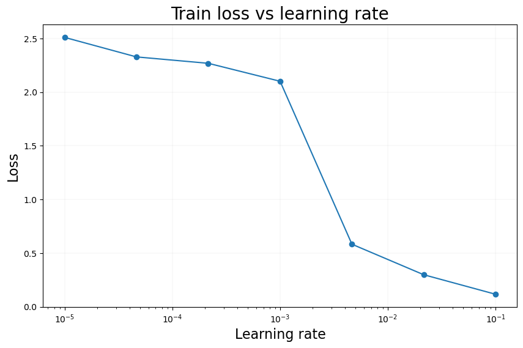

```python
# Set figure size.
plt.figure(figsize=(10, 6))

# Plot the loss vs learning rate.
plt.plot(lr_range, losses, marker='o')

# Customize the plot.
plt.grid(visible=True, linewidth=0.1)
plt.title('Train loss vs learning rate', fontsize=20)
plt.xlabel('Learning rate', fontsize=16)
plt.ylabel('Loss', fontsize=16)
plt.xticks(fontsize=10)
plt.yticks(fontsize=10)
plt.xscale("log")

# Show the plot.
plt.show()
```

We restrict our range for $\lambda$ in order to make sure that the optimal value of the learning rate is indeed $0.1$.

```python
# Parameters for MLP
lr_range = [0.04, 0.05, 0.06, 0.07, 0.08, 0.09, 0.1]
batch_size = 128
num_epochs = 40

losses = []
for lr in lr_range:
    # Initialise the network.
    mlp = MLP(
        LinearLayer(200),
        SoftplusLayer(),
        LinearLayer(200),
        SoftplusLayer(),
        LinearLayer(200),
        SoftplusLayer(),
        LinearLayer(10),
        SoftmaxLayer()
    )

    # Initialise the trainer.
    trainer = Trainer(
        network=mlp,
        loss=KLDivergenceLoss(),
        batch_size=batch_size,
        num_epochs=num_epochs,
        learning_rate=lr,
    )

    # Train the network and compute the loss.
    trainer.train((X_train, y_train))
    loss = trainer.eval_loss(X_train, y_train)
    losses.append(loss)
```

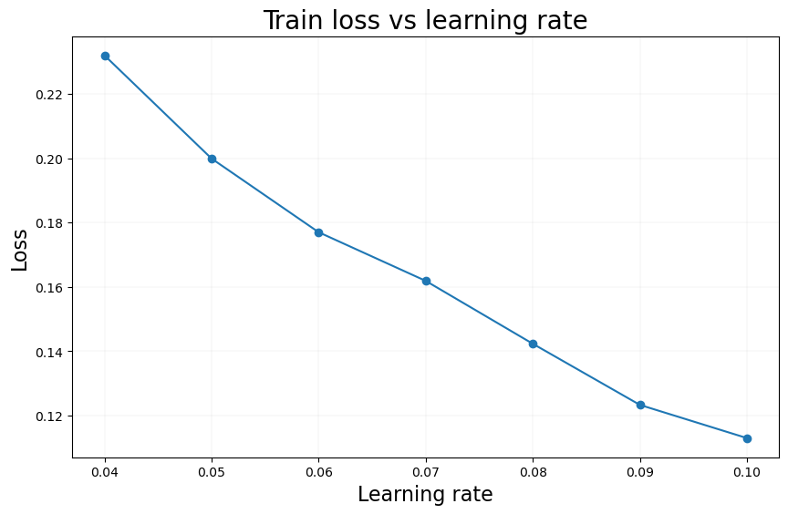

```python
# Set figure size.
plt.figure(figsize=(10, 6))

# Plot the loss vs learning rate.
plt.plot(lr_range, losses, marker='o')

# Customize the plot.
plt.grid(visible=True, linewidth=0.1)
plt.title('Train loss vs learning rate', fontsize=20)
plt.xlabel('Learning rate', fontsize=16)
plt.ylabel('Loss', fontsize=16)
plt.xticks(fontsize=10)
plt.yticks(fontsize=10)

# Show the plot.
plt.show()
```

```python
# Parameters for MLP
lr_range = [0.09, 0.092, 0.094, 0.096, 0.098, 0.1]
batch_size = 128
num_epochs = 40

losses = []  # list of losses
for lr in lr_range:
    # Initialise the network.
    mlp = MLP(
        LinearLayer(200),
        SoftplusLayer(),
        LinearLayer(200),
        SoftplusLayer(),
        LinearLayer(200),
        SoftplusLayer(),
        LinearLayer(10),
        SoftmaxLayer()
    )

    # Initialise the trainer.
    trainer = Trainer(
        network=mlp,
        loss=KLDivergenceLoss(),
        batch_size=batch_size,
        num_epochs=num_epochs,
        learning_rate=lr,
    )

    # Train the network and compute the loss.
    trainer.train((X_train, y_train))
    loss = trainer.eval_loss(X_train, y_train)
    losses.append(loss)
```

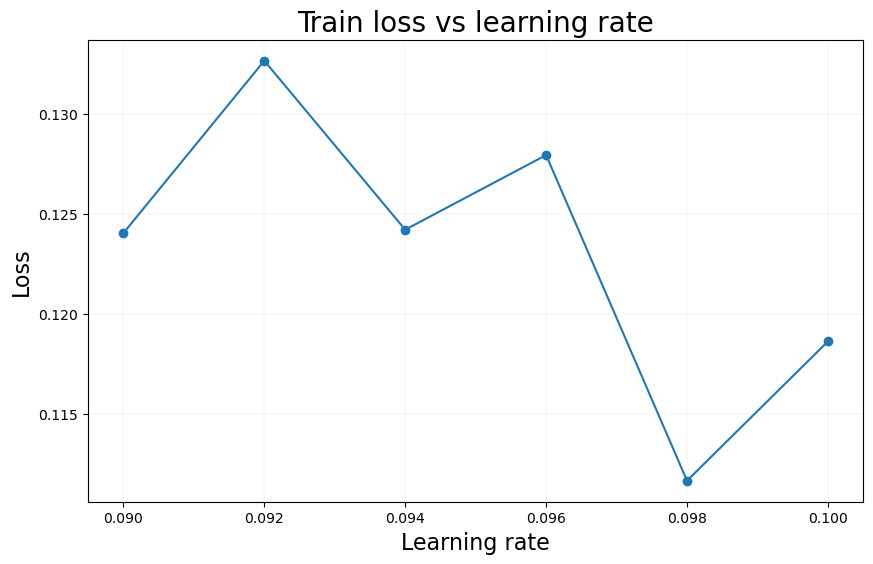

```python
# Set figure size.
plt.figure(figsize=(10, 6))

# Plot the loss vs learning rate.
plt.plot(lr_range, losses, marker='o')

# Customize the plot.
plt.grid(visible=True, linewidth=0.1)
plt.title('Train loss vs learning rate', fontsize=20)
plt.xlabel('Learning rate', fontsize=16)
plt.ylabel('Loss', fontsize=16)
plt.xticks(fontsize=10)
plt.yticks(fontsize=10)

# Show the plot.
plt.show()
```

We notice that if the training loss is too small, the network is unable to learn the features of the data. But if we increase the learning rate, the loss starts decreasing since the model is becoming capable of learning the structure of the data.

This trend can also be caused by the following reasons:

- The number of epochs is set to $40$, which might be too small for the model to learn the structure of the data. Hence, we could increase the number of epochs and see if the trend changes.
- The batch size is set to $128$, which might be too small for the model to learn the structure of the data. Hence, we could increase the batch size and see if the trend changes.

If we want to improve the model even further, we could use an adaptive learning rate. This would allow us to have a higher learning rate at the beginning of the training and then decrease it as the training progresses.

#### 1.1.2

```python
optimal_lr = 0.1
```

Retrain the MLP with it, using batches of $128$ data points and $40$ epochs.

```python
batch_size = 128  # batch size
num_epochs = 40  # number of epochs

# Initialise the network.
mlp_200 = MLP(
    LinearLayer(200),
    SoftplusLayer(),
    LinearLayer(200),
    SoftplusLayer(),
    LinearLayer(200),
    SoftplusLayer(),
    LinearLayer(10),
    SoftmaxLayer()
)

# Initialise the trainer.
trainer = Trainer(
    network=mlp_200,
    loss=KLDivergenceLoss(),
    batch_size=batch_size,
    num_epochs=num_epochs,
    learning_rate=optimal_lr,
)

# Train the network.
train_loss, train_accuracy, test_loss, test_accuracy = trainer.train(
    (X_train, y_train),
    val_dataset=(X_test, y_test),
    return_intermediate_results=True,
)

# Store the training and test accuracy.
mlp_200_train_accuracy = trainer.eval_accuracy(X_train, y_train)
mlp_200_test_accuracy = trainer.eval_accuracy(X_test, y_test)
```

Plot the loss and the accuracy of the trained MLP as a function of the number of epochs for both the training and test sets.

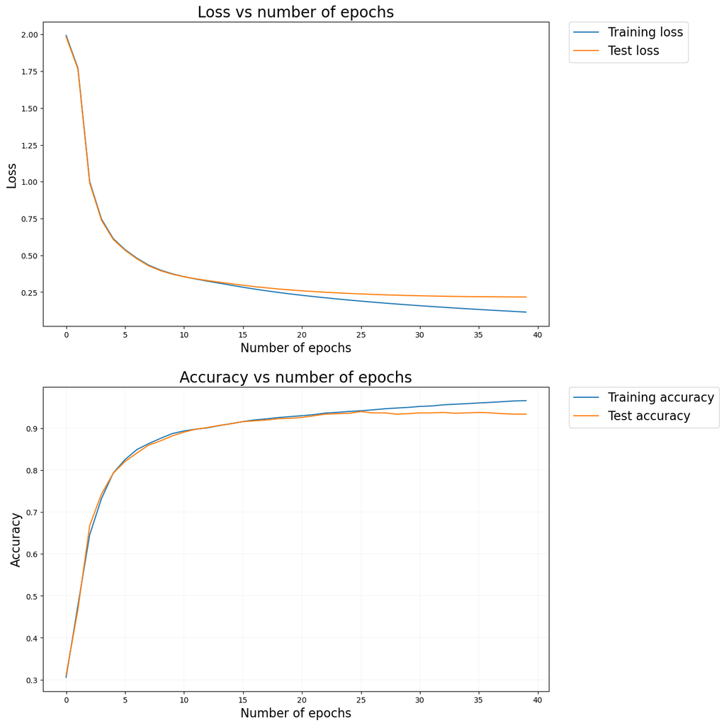

```python
# Set figure size.
fig, axs = plt.subplots(nrows=2, ncols=1, figsize=(12, 16))

# Customize the plot.
plt.grid(visible=True, linewidth=0.1)
plt.xticks(fontsize=10)
plt.yticks(fontsize=10)

# Plot the loss as a function of number of epochs.
axs[0].plot(range(num_epochs), train_loss, label="Training loss")
axs[0].plot(range(num_epochs), test_loss, label="Test loss")
# Customize the plot.
axs[0].set_title("Loss vs number of epochs", fontsize=20)
axs[0].set_xlabel("Number of epochs", fontsize=16)
axs[0].set_ylabel("Loss", fontsize=16)
axs[0].legend(
    bbox_to_anchor=(1.04, 1),
    borderaxespad=0,
    loc="upper left",
    fontsize=16,
)

# Plot the accuracy as a function of number of epochs.
axs[1].plot(range(num_epochs), train_accuracy, label="Training accuracy")
axs[1].plot(range(num_epochs), test_accuracy, label="Test accuracy")
# Customize the plot.
axs[1].set_title("Accuracy vs number of epochs", fontsize=20)
axs[1].set_xlabel("Number of epochs", fontsize=16)
axs[1].set_ylabel("Accuracy", fontsize=16)
axs[1].legend(
    bbox_to_anchor=(1.04, 1),
    borderaxespad=0,
    loc="upper left",
    fontsize=16,
)

# Show the plot.
plt.show()
```

Based on the plots, we can see convergence of the training/test losses and accuracy although we have only $40$ epochs. This means the model is able to learn the structure of the data, despite the low number of epochs. Moreover, the model is not overfitting since there is not much difference between the training/test losses and accuracy.

#### 1.1.3

Using the optimal learning rate, we retrain the MLP of task 1.1.2 reducing the hidden layer width to $50$.

```python
batch_size = 128  # batch size
num_epochs = 40  # number of epochs

# Initialise the network.
mlp_50 = MLP(
    LinearLayer(50),
    SoftplusLayer(),
    LinearLayer(50),
    SoftplusLayer(),
    LinearLayer(50),
    SoftplusLayer(),
    LinearLayer(10),
    SoftmaxLayer()
)

# Initialise the trainer.
trainer = Trainer(
    network=mlp_50,
    loss=KLDivergenceLoss(),
    batch_size=batch_size,
    num_epochs=num_epochs,
    learning_rate=optimal_lr,
)

# Train the network.
train_loss, train_accuracy, test_loss, test_accuracy = trainer.train(
    (X_train, y_train),
    val_dataset=(X_test, y_test),
    return_intermediate_results=True,
)

# Store the training and test accuracy.
mlp_50_train_accuracy = trainer.eval_accuracy(X_train, y_train)
mlp_50_test_accuracy = trainer.eval_accuracy(X_test, y_test)
```

Plot the loss and the accuracy of the trained MLP as a function of the number of epochs for both the training and test sets.

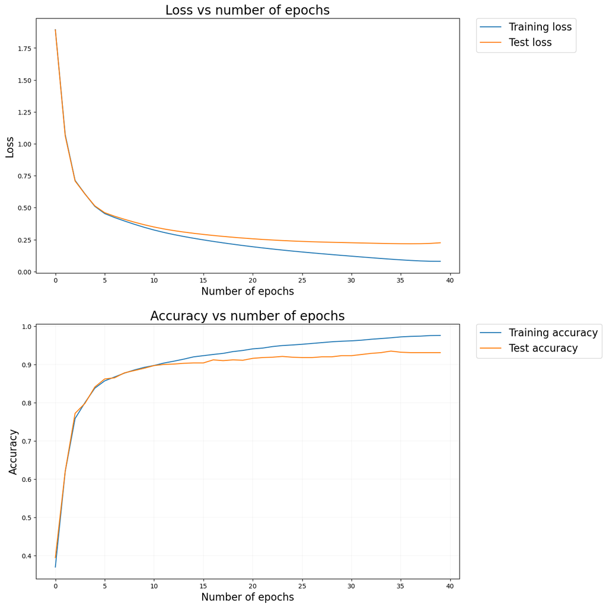

```python
# Set figure size.
fig, axs = plt.subplots(nrows=2, ncols=1, figsize=(12, 16))

# Customize the plot.
plt.grid(visible=True, linewidth=0.1)
plt.xticks(fontsize=10)
plt.yticks(fontsize=10)

# Plot the loss as a function of number of epochs.
axs[0].plot(range(num_epochs), train_loss, label="Training loss")
axs[0].plot(range(num_epochs), test_loss, label="Test loss")
# Customize the plot.
axs[0].set_title("Loss vs number of epochs", fontsize=20)
axs[0].set_xlabel("Number of epochs", fontsize=16)
axs[0].set_ylabel("Loss", fontsize=16)
axs[0].legend(
    bbox_to_anchor=(1.04, 1),
    borderaxespad=0,
    loc="upper left",
    fontsize=16,
)

# Plot the accuracy as a function of number of epochs.
axs[1].plot(range(num_epochs), train_accuracy, label="Training accuracy")
axs[1].plot(range(num_epochs), test_accuracy, label="Test accuracy")
# Customize the plot.
axs[1].set_title("Accuracy vs number of epochs", fontsize=20)
axs[1].set_xlabel("Number of epochs", fontsize=16)
axs[1].set_ylabel("Accuracy", fontsize=16)
axs[1].legend(
    bbox_to_anchor=(1.04, 1),
    borderaxespad=0,
    loc="upper left",
    fontsize=16,
)

# Show the plot.
plt.show()
```

We evaluate the accuracy of both MLP models on the training and test sets.

```python
pd.DataFrame(
    [
        [mlp_200_train_accuracy, mlp_200_test_accuracy],
        [mlp_50_train_accuracy, mlp_50_test_accuracy],
    ],
    columns=["Training accuracy", "Test accuracy"],
    index=["MLP 200", "MLP 50"],
)
```

|  | Training accuracy | Test accuracy |
| --- | --- | --- |
| MLP 200 | 0.966167 | 0.934 |
| MLP 50 | 0.976000 | 0.931 |

By looking at the plots, we see an almost identical behaviour to the previous model. Even though the number of epochs was small, the model was able to effectively grasp the data's structure, with the losses and accuracy rapidly reaching convergence. Moreover, the model is not overfitting since there is not much difference between the training/test losses and accuracy.

Since the model has similar performance and losses with the previous one, we can infer that reducing the number of neurons in the hidden layer might be a good choice for this task because:

- We can avoid overfitting the model to the training data.
- The number of parameters decreases and hence the model is less complex. Moreover, it would take less time to train the model.
- By reducing the number of neurons, you can make the network more robust to noise.
- Neural networks with fewer neurons can be regularized more easily than larger ones.

*Note.* The losses and accuracy of both models are quite similar, but that doesn't necessarily mean that the models would have the same performance in all situations. One could try to compare the two models using other losses (e.g. cross-entropy) or metrics (e.g. precision, recall, specificity, F1-score, etc.) in order to see if there is truly no difference between the two.

#### 1.1.4

```python
lr_range = np.logspace(-2, 0, base=10, num=7)  # learning range
batch_size = 128  # batch size
num_epochs = 80  # number of epochs

losses = []  # list of losses
for lr in lr_range:
    # Initialise the network.
    mlp = MLP(
        LinearLayer(200),
        SoftplusLayer(),
        DropoutLayer(rate=0.2),
        LinearLayer(200),
        SoftplusLayer(),
        DropoutLayer(rate=0.2),
        LinearLayer(200),
        SoftplusLayer(),
        DropoutLayer(rate=0.2),
        LinearLayer(10),
        SoftmaxLayer()
    )

    # Initialise the trainer.
    trainer = Trainer(
        network=mlp,
        loss=KLDivergenceLoss(),
        batch_size=batch_size,
        num_epochs=num_epochs,
        learning_rate=lr,
    )

    # Train the network and compute the loss.
    trainer.train((X_train, y_train))
    loss = trainer.eval_loss(X_train, y_train)
    losses.append(loss)
```

Plot the losses.

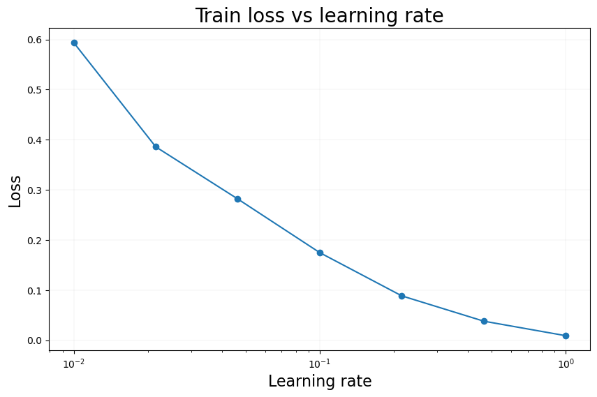

```python
# Plot the loss vs learning rate.
plt.figure(figsize=(10, 6))

# Plot the loss vs learning rate.
plt.plot(lr_range, losses, marker='o')

# Customize the plot.
plt.grid(visible=True, linewidth=0.1)
plt.title('Train loss vs learning rate', fontsize=20)
plt.xlabel('Learning rate', fontsize=16)
plt.ylabel('Loss', fontsize=16)
plt.xticks(fontsize=10)
plt.yticks(fontsize=10)
plt.xscale("log")

# Show the plot.
plt.show()
```

Let's restrict the range in order to find the optimal value of the learning rate.

```python
# Parameters for MLP model.
lr_range = [0.8, 0.9, 1, 1.1, 1.2, 1.3, 1.4]
batch_size = 128
num_epochs = 80

losses = []
for lr in lr_range:
    # Initialise the network.
    mlp = MLP(
        LinearLayer(200),
        SoftplusLayer(),
        DropoutLayer(rate=0.2),
        LinearLayer(200),
        SoftplusLayer(),
        DropoutLayer(rate=0.2),
        LinearLayer(200),
        SoftplusLayer(),
        DropoutLayer(rate=0.2),
        LinearLayer(10),
        SoftmaxLayer()
    )

    # Initialise the trainer.
    trainer = Trainer(
        network=mlp,
        loss=KLDivergenceLoss(),
        batch_size=batch_size,
        num_epochs=num_epochs,
        learning_rate=lr,
    )

    # Train the network and compute the loss.
    trainer.train((X_train, y_train))
    loss = trainer.eval_loss(X_train, y_train)
    losses.append(loss)
```

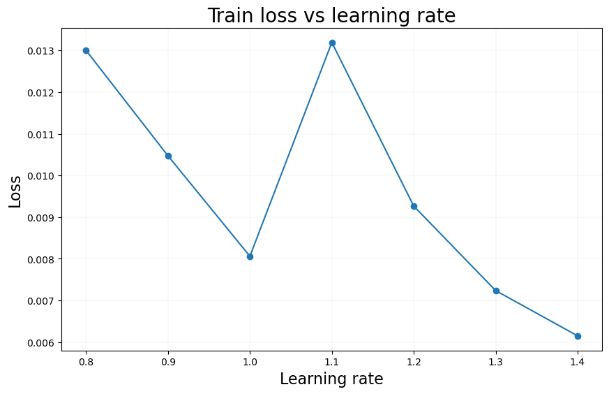

```python
# Plot the loss vs learning rate.
plt.figure(figsize=(10, 6))

# Plot the loss vs learning rate.
plt.plot(lr_range, losses, marker='o')

# Customize the plot.
plt.grid(visible=True, linewidth=0.1)
plt.title('Train loss vs learning rate', fontsize=20)
plt.xlabel('Learning rate', fontsize=16)
plt.ylabel('Loss', fontsize=16)
plt.xticks(fontsize=10)
plt.yticks(fontsize=10)

# Show the plot.
plt.show()
```

Find the optimal learning rate.

```python
# Compute the optimal learning rate.
optimal_lr = lr_range[np.argmin(losses)]

# Print the optimal learning rate.
print(f"Optimal learning rate: {optimal_lr}")
```

```
Optimal learning rate: 1.4
```

Retrain the MLP with it, using batches of $128$ data points and $80$ epochs.

```python
batch_size = 128  # batch size
num_epochs = 80  # number of epochs

# Initialise the network.
mlp_200_with_dropout = MLP(
    LinearLayer(200),
    SoftplusLayer(),
    DropoutLayer(rate=0.2),
    LinearLayer(200),
    SoftplusLayer(),
    DropoutLayer(rate=0.2),
    LinearLayer(200),
    SoftplusLayer(),
    DropoutLayer(rate=0.2),
    LinearLayer(10),
    SoftmaxLayer()
)

# Initialise the trainer.
trainer = Trainer(
    network=mlp_200_with_dropout,
    loss=KLDivergenceLoss(),
    batch_size=batch_size,
    num_epochs=num_epochs,
    learning_rate=optimal_lr,
)

# Train the network.
train_loss, train_accuracy, test_loss, test_accuracy = trainer.train(
    (X_train, y_train),
    val_dataset=(X_test, y_test),
    return_intermediate_results=True,
)

# Store the training and test accuracy.
mlp_200_with_dropout_train_accuracy = trainer.eval_accuracy(X_train, y_train)
mlp_200_with_dropout_test_accuracy = trainer.eval_accuracy(X_test, y_test)
```

Plot the loss and the accuracy of the trained MLP as a function of the number of epochs for both the training and test sets.

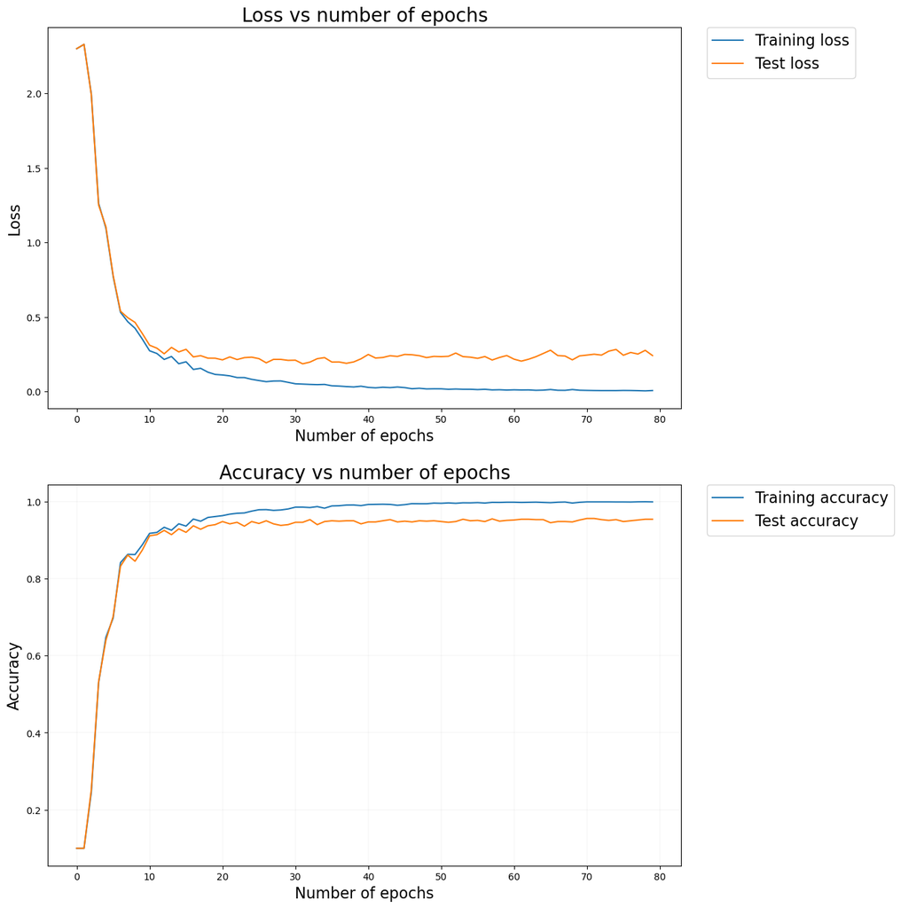

```python
# Set figure size.
fig, axs = plt.subplots(nrows=2, ncols=1, figsize=(12, 16))

# Customize the plot.
plt.grid(visible=True, linewidth=0.1)
plt.xticks(fontsize=10)
plt.yticks(fontsize=10)

# Plot the loss as a function of number of epochs.
axs[0].plot(range(num_epochs), train_loss, label="Training loss")
axs[0].plot(range(num_epochs), test_loss, label="Test loss")
# Customize the plot.
axs[0].set_title("Loss vs number of epochs", fontsize=20)
axs[0].set_xlabel("Number of epochs", fontsize=16)
axs[0].set_ylabel("Loss", fontsize=16)
axs[0].legend(
    bbox_to_anchor=(1.04, 1),
    borderaxespad=0,
    loc="upper left",
    fontsize=16,
)

# Plot the accuracy as a function of number of epochs.
axs[1].plot(range(num_epochs), train_accuracy, label="Training accuracy")
axs[1].plot(range(num_epochs), test_accuracy, label="Test accuracy")
# Customize the plot.
axs[1].set_title("Accuracy vs number of epochs", fontsize=20)
axs[1].set_xlabel("Number of epochs", fontsize=16)
axs[1].set_ylabel("Accuracy", fontsize=16)
axs[1].legend(
    bbox_to_anchor=(1.04, 1),
    borderaxespad=0,
    loc="upper left",
    fontsize=16,
)

# Show the plot.
plt.show()
```

Plot histograms of the activations of the units in the first hidden layer when the network is evaluated on a batch of the test data, both for the network with dropout and without dropout.

```python
batch_size = 128  # batch size

# Split the data into batches.
input_batches, target_batches = split_into_batches(
    X_test, y_test, batch_size,
)

# Pick a batch.
batch_index = 0
input_batch = input_batches[batch_index]
target_batch = target_batches[batch_index]

# Extract the first layer and its activation.
first_linear_layer = mlp_200.layers[0]
first_activation_layer = mlp_200.layers[1]
# Compute the first layer activations.
mlp_200_first_layer_activations = first_activation_layer.forward(
    first_linear_layer.forward(input_batch)
).flatten()

# Extract the first layer and its activation.
first_linear_layer = mlp_200_with_dropout.layers[0]
first_activation_layer = mlp_200_with_dropout.layers[1]
# Compute the first layer activations.
mlp_200_with_dropout_first_layer_activations = first_activation_layer.forward(
    first_linear_layer.forward(input_batch)
).flatten()
```

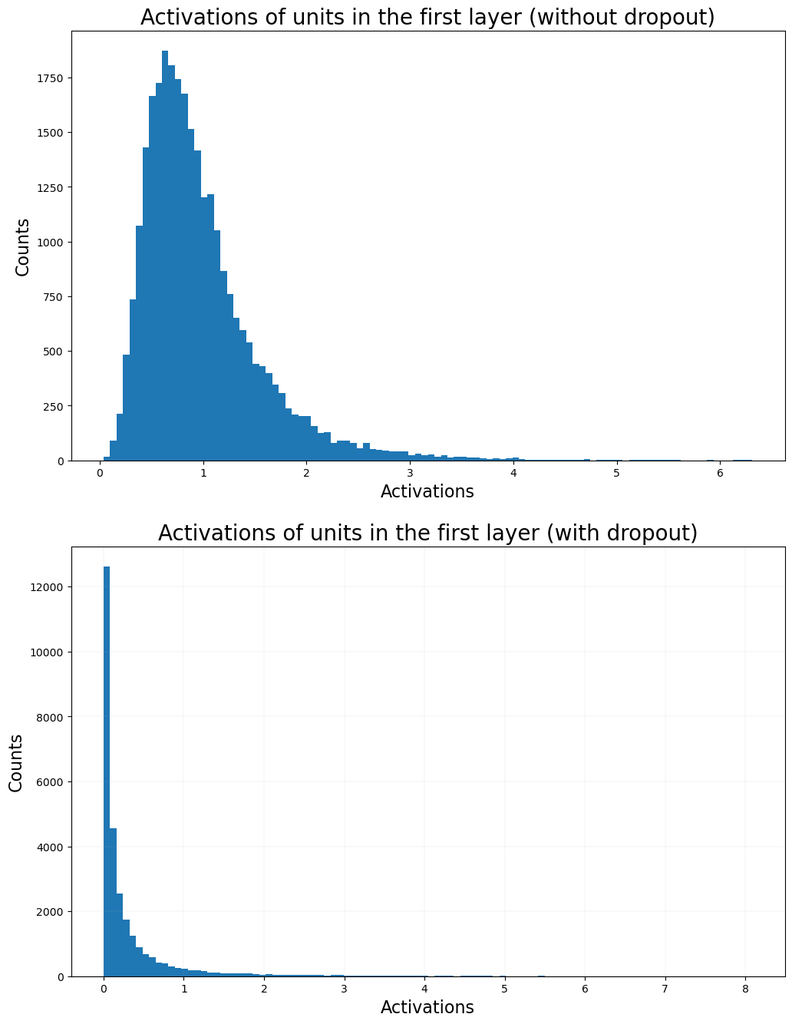

```python
# Set figure size.
fig, axs = plt.subplots(nrows=2, ncols=1, figsize=(12, 16))

# Customize the plot.
plt.grid(visible=True, linewidth=0.1)
plt.xticks(fontsize=10)
plt.yticks(fontsize=10)

# Plot the activations.
axs[0].hist(mlp_200_first_layer_activations, bins=100)
# Customize the plot.
axs[0].set_title("Activations of units in the first layer (without dropout)", fontsize=20)
axs[0].set_xlabel("Activations", fontsize=16)
axs[0].set_ylabel("Counts", fontsize=16)

# Plot the activations.
axs[1].hist(mlp_200_with_dropout_first_layer_activations, bins=100)
# Customize the plot.
axs[1].set_title("Activations of units in the first layer (with dropout)", fontsize=20)
axs[1].set_xlabel("Activations", fontsize=16)
axs[1].set_ylabel("Counts", fontsize=16)

# Show the plot.
plt.show()
```

Let's also plot the activations on the same plot.

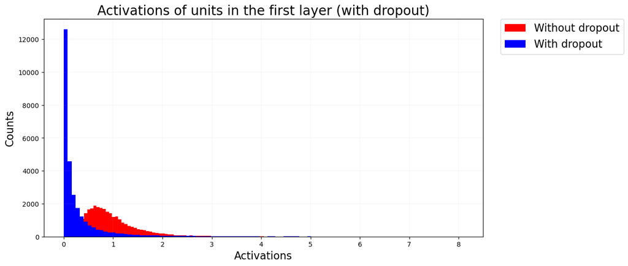

```python
# Set figure size.
plt.figure(figsize=(12, 6))

# Plot the activations.
plt.hist(
    mlp_200_first_layer_activations,
    bins=100, color="red", label="Without dropout",
)
plt.hist(
    mlp_200_with_dropout_first_layer_activations,
    bins=100, color="blue", label="With dropout",
)

# Customize the plot.
plt.grid(visible=True, linewidth=0.1)
plt.title("Activations of units in the first layer (with dropout)", fontsize=20)
plt.xlabel('Activations', fontsize=16)
plt.ylabel('Counts', fontsize=16)
plt.xticks(fontsize=10)
plt.yticks(fontsize=10)
plt.legend(
    bbox_to_anchor=(1.04, 1),
    borderaxespad=0,
    loc="upper left",
    fontsize=16,
)

# Show the plot.
plt.show()
```

Let's look at the results with and without dropout.

```python
pd.DataFrame(
    [
        [mlp_200_train_accuracy, mlp_200_test_accuracy],
        [mlp_200_with_dropout_train_accuracy, mlp_200_with_dropout_test_accuracy],
    ],
    columns=["Training accuracy", "Test accuracy"],
    index=["MLP 200 (without dropout)", "MLP 200 (with dropout)"],
)
```

|  | Training accuracy | Test accuracy |
| --- | --- | --- |
| MLP 200 (without dropout) | 0.966167 | 0.934 |
| MLP 200 (with dropout) | 0.999000 | 0.954 |

Introducing dropout has the following benefits:

- It makes the network more robust to noise in the input data and reduces its dependence on specific features.
- It can improve the generalization performance of the network by forcing it to learn multiple independent representations of the input data.
- It can prevent neurons from co-adapting (i.e. when multiple neurons learn to depend on each other to make accurate predictions).
- It can make the network more robust to adversarial attacks (i.e. attempts to manipulate the input data to produce incorrect predictions).

By looking at the loss and accuracy plots, we see that:

- The model was able to learn the structure of the data, with the losses and accuracy rapidly reaching convergence.
- The model is not overfitting since there is not much difference between the training/test losses and accuracy.

By looking at the histograms, we see that they are quite different.

- The dropout had the intended effect of making the activations more small, close to $0$, and with smaller variance. This is a desired behaviour since we want the model to learn general features in the first layers (hence we want smaller activations here) and specific features in the later layers.
- From this we can infer that the two models might learn different representations of the input data, which can have implications on the generalization performance of the network.

### 1.2 Dimensionality reduction (20 marks)

#### 1.2.0 PCA and NMF

We implement functions for normalising the data.

```python
class StandardNormalizer:

    def __init__(self):
        """ Initialize the normalizer. """
        pass

    def fit(self, X):
        """
        Fit the normalizer to the data X.

        Parameters
        ----------
        :param X: {np.ndarray} of shape (num_points, num_features) --
            Data array.
        """

        # Get the sample means of the columns.
        mean = np.mean(X, axis=0)

        # Get the sample standard deviations of the columns.
        std = np.std(X, axis=0)
        std_filled = std.copy()
        std_filled[std == 0] = 1

        # Store the mean and standard deviation.
        self.mean = mean
        self.std_filled = std_filled

    def transform(self, X):
        """
        Transform the data X.

        Parameters
        ----------
        :param X: {np.ndarray} of shape (num_points, num_features) --
            Data array.

        Returns
        ----------
        :rtype: {np.ndarray} of shape (num_points, num_features)
        :return: Normalised version of X.
        """

        # Get the normalised version of X.
        X_normalised = (X - self.mean) / self.std_filled

        return X_normalised

    def inverse_transform(self, X):
        """
        Transform the data X.

        Parameters
        ----------
        :param X: {np.ndarray} of shape (num_points, num_features) --
            Data array.

        Returns
        ----------
        :rtype: {np.ndarray} of shape (num_points, num_features)
        :return: Initial value of X (before normalization).
        """

        return X * self.std_filled + self.mean
```

```python
class MinMaxNormalizer:
    def __init__(self):
        """ Initialize the normalizer. """
        pass

    def fit(self, X):
        """
        Fit the normalizer to the data X.

        Parameters
        ----------
        :param X: {np.ndarray} of shape (num_points, num_features) --
            Data array.
        """

        # Get the min and max.
        min = np.min(X)
        max = np.max(X)

        # Store the min and max.
        self.min = min
        self.max = max

    def transform(self, X):
        """
        Transform the data X.

        Parameters
        ----------
        :param X: {np.ndarray} of shape (num_points, num_features) --
            Data array.

        Returns
        ----------
        :rtype: {np.ndarray} of shape (num_points, num_features)
        :return: Normalised version of X using min-max.
        """

        # Get the min-max normalisation.
        X_normalised = (X - self.min) / (self.max - self.min)

        return X_normalised

    def inverse_transform(self, X):
        """
        Transform the data X.

        Parameters
        ----------
        :param X: {np.ndarray} of shape (num_points, num_features) --
            Data array.

        Returns
        ----------
        :rtype: {np.ndarray} of shape (num_points, num_features)
        :return: Initial value of X (before normalization).
        """

        return X * (self.max - self.min) + self.min
```

**Principal Component Analysis** (**PCA**) is a popular technique used to reduce the dimensionality of a dataset while retaining as much information as possible.

It finds a new set of variables, known as principal components, which are linear combinations of the original variables. They are ordered in terms of the amount of variability they explain in the data.

By reducing the number of variables in a dataset, we simplify our analysis while still retaining the most important information. PCA can also help identify patterns and relationships within the data. Moreover, it can be used for data visualization and clustering.

We now implement it. Let $X$ be a dataset and suppose that we have $m$ principal components. The algorithm goes as follows:

1. Compute the covariance matrix $C = \frac{1}{n - 1} X^T X$.
2. Find eigenvalues and corresponding eigenvectors for the covariance matrix $C = V L V^T$.
3. Sort by the largest eigenvalues and the corresponding eigenvectors.
4. Compute the projection onto the spaced spanned by the top $n$ eigenvectors.

```python
class PCA:
    """
    PCA object.

    Attributes
    ----------
    :attr num_components: {int} --
        Number of principal components to keep.

    :attr eigenvalues: {np.ndarray} of shape (num_components,) --
        Eigenvalues of the covariance matrix.

    :attr eigenvectors: {np.ndarray} of shape (num_features, num_components) --
        Eigenvectors of the covariance matrix.

    :attr explained_variance: {np.ndarray} of shape (num_components,) --
        Explained variance.

    :attr explained_variance_cumulative: {np.ndarray} of shape (num_components,) --
        Cumulative explained variance.
    """

    def __init__(self, num_components):
        """
        Initialize the PCA object.

        Parameters
        ----------
        :param num_components: {int} --
            Number of principal components to keep.
        """

        self.num_components = num_components

    def fit(self, data):
        """
        Fit the PCA model to the data array X.

        Parameters
        ----------
        :param X: {np.ndarray} of shape (num_points, num_features) --
            Data array.
        """

        num_points = data.shape[0]

        # Store the normalizer.
        self._normalizer = StandardNormalizer()
        self._normalizer.fit(data)

        # Normalize the data.
        data = self._normalizer.transform(data)

        # Create the covariance matrix.
        C = np.dot(data.T, data) / (num_points - 1)

        # Compute eigenvalues and eigenvectors using the eigsh scipy function.
        eigenvalues, eigenvectors = linalg.eigsh(
            C, self.num_components,
            which="LM",
            return_eigenvectors=True
        )

        # Sort the eigenvectors and eigenvalues from largest to smallest eigenvalue.
        sorted_index = np.argsort(eigenvalues)[::-1]
        eigenvalues = eigenvalues[sorted_index]
        eigenvectors = eigenvectors[:, sorted_index]

        # Compute the variance explained by each principal component.
        all_eigenvalues, _ = np.linalg.eig(C)
        total_variance = abs(np.sum(all_eigenvalues))
        explained_variance_ratio = eigenvalues / total_variance

        # Store data.
        self.eigenvectors = eigenvectors
        self.eigenvalues = eigenvalues
        self.explained_variance_ratio = explained_variance_ratio
        self.explained_variance_cumulative = np.cumsum(explained_variance_ratio)

    def transform(self, X):
        """
        Transform the data X.

        Parameters
        ----------
        :param X: {np.ndarray} of shape (num_points, num_features) --
            Data array.

        Returns
        ----------
        :rtype: {np.ndarray} of shape (num_points, num_components)
        :return: Data array transformed by the PCA.
        """

        X_normalized = self._normalizer.transform(X)

        return X_normalized.dot(self.eigenvectors)

    def inverse_transform(self, X):
        """
        Transform the data X.

        Parameters
        ----------
        :param X: {np.ndarray} of shape (num_points, num_components) --
            Data array.

        Returns
        ----------
        :rtype: {np.ndarray} of shape (num_points, num_features)
        :return: Data array inverse transformed by the PCA.
        """

        X_inverse_transformed = X.dot(self.eigenvectors.T)

        return self._normalizer.inverse_transform(X_inverse_transformed)

    def find_num_of_components_needed(self, threshold):
        """
        Return the number of components needed to explain the threshold of the variance.

        Parameters
        ----------
        :param threshold: {float} --
            Threshold of the variance to be explained.

        Returns:
        ----------
        :rtype: {int}
        :return: Number of components needed to explain the threshold of the variance.
        """

        # Get the number of components needed to explain the threshold of the variance.
        num_components_needed = np.argmax(self.explained_variance_cumulative >= threshold) + 1

        return num_components_needed

    def variance_explained_by(self, m):
        """
        Return the variance explained by m principal components.

        Parameters
        ----------
        :param m: {int} --
            Number of principal components.

        Returns:
        ----------
        :rtype: {float}
        :return: Variance explained by m principal components.
        """

        return self.explained_variance_cumulative[m - 1]
```

**Nonnegative Matrix Factorization** (**NMF**) is an algorithm used for decomposing a nonnegative matrix into two lower-dimensional nonnegative matrices. Unlike Singular Value Decomposition (SVD), which allows for negative values in the decomposed matrices, NMF enforces the non-negativity constraint. This can be useful in cases where the underlying data has nonnegative properties.

In NMF, a nonnegative matrix $A$ is factorized into two nonnegative matrices $W$ and $H$, such that $A \approx WH$.

1. The matrix $W$ contains the basis vectors, which are used to approximate the original matrix $A$.
2. The matrix $H$ contains the coefficients, which are used to weight the basis vectors.

The goal of NMF is to find the best approximation of $A$ by minimizing the reconstruction error, which is typically measured using the Frobenius norm or the Kullback-Leibler divergence.

For this, we are going to use the **chi2 loss function**:

$$ \chi ^ 2 = \frac{e^⊤ (X \odot d \odot d) e}{n} $$

where

- $d$ is the difference $d = X - WH$,
- $e$ is a vector of all ones ($e^⊤ K e$ simply performs a sum over all elements in $K$),
- $n$ is the total number of elements in $X$.

The symbol $\odot$ is the element wise product (Hadamard product).

Let's start with implementing the loss function.

```python
def chi2_cost(X, W, H):
    """
    Return the cost for the data matrix X and the current W and H components.

    Parameters
    ----------
    :param data: {np.ndarray} of shape (num_samples, num_features) --
        Data array.
    :param W: {np.ndarray} of shape (num_samples, num_components) --
        W component of the NMF model.
    :param H: {np.ndarray} of shape (num_components, num_features) --
        H component of the NMF model.

    Returns:
    ----------
    :rtype: {scalar}
    :return: The chi2 cost for the data matrix X and the current W and H components.
    """

    # Get the difference between X and the product of W and H (matrix multiplication).
    diff = X - W @ H

    # Get the chi2 cost.
    chi2 = ((X * diff) * diff).sum() / (X.shape[0] * X.shape[1])

    return chi2
```

We now implement the NMF.

The algorithm factors our $n \times m$ feature matrix $X$ into nonnegative factors $W$ ($n \times k$) and $H$ ($k \times m$). The factorization is not exact. $WH$ is a lower-rank approximation to $A$. The factors $W$ and $H$ minimize the root mean square residual $D$ between $X$ and $WH$.

Note that for non-negative matrix factorisation we require the input matrix to be non-negative. Therefore, we must normalise between $0$ and $1$ instead of standard normalise which we used for PCA and SVD.

Here we will use Lee and Seung's multiplicative update rule.

$$ \mathbf{H}_{[i,j]}^{n+1} \leftarrow \mathbf{H}_{[i,j]}^{n} \frac{(( \mathbf{W}^n)^T \mathbf{X})_{[i,j]}}{((\mathbf{W}^n)^T \mathbf{W}^n \mathbf{H}^n)_{[i,j]}} $$

and

$$ \mathbf{W}_{[i,j]}^{n+1} \leftarrow \mathbf{W}_{[i,j]}^{n} \frac{(\mathbf{X}(\mathbf{H}^{n+1})^T)_{[i,j]}}{(\mathbf{W}^n \mathbf{H}^{n+1} (\mathbf{H}^{n+1})^T)_{[i,j]}} $$

until $W$ and $H$ are stable. It is important to note that updates are done on an element by element basis and not matrix multiplication.

Notice that although the `inverse_transform()` function is pretty straightforward to implement (you just need to multiply by $H$ and rescale the data), that's not the case for `transform()`. In this case, we also need to find a new $W$ (basis vectors) keeping the $H$ (coefficients) fixed.

```python
class NMF:

    def __init__(
            self,
            num_components,
            num_iterations=1000,
            seed=None,
    ):
        """
        Initialise the model.

        Parameters
        ----------
        :param num_components: {int} --
            The number of components to use.
        :param num_iterations: {int}, optional, default=1000 --
            The number of iterations to use.
        :param seed: {int}, optional, default=None --
            The seed to use for initialisation.
        """

        self.num_components = num_components
        self.num_iterations = num_iterations
        self.seed = seed

    def fit(self, data):
        """
        Fit the model to the data.

        Parameters
        ----------
        :param data: {numpy.ndarray} of shape (num_samples, num_features) --
            The data to fit the model to.

        Returns
        -------
        :rtype: {list} of {scalar}
        :return: The cost values for each iteration.
        """

        num_samples, num_features = data.shape

        # Store the normalizer.
        self._normalizer = MinMaxNormalizer()
        self._normalizer.fit(data)

        # Normalise the data.
        data = self._normalizer.transform(data)

        # Set the random generator.
        rng = np.random.default_rng(self.seed)

        # Initialisation of the (num_samples) x (num_components) components matrix,
        # usually interpreted as the coefficients.
        W = rng.random((num_samples, self.num_components))

        # Initialisation of the (num_componets) x (num_features) matrix,
        # usually interpreted as the basis set.
        H = rng.random((self.num_components, num_features))

        scores = []

        for _ in range(self.num_iterations):
            # Update H.
            H = H * ((W.T.dot(data)) / W.T.dot(W.dot(H)))

            # Update W.
            W = W * ((data.dot(H.T)) / (W.dot(H.dot(H.T))))

            # Compute the chi2 cost at this iteration and append it to the list.
            scores.append(chi2_cost(data, W, H))

        # Store W and H.
        self.W = W
        self.H = H

        return scores

    def transform(self, X):
        """
        Transform the data X.

        Parameters
        ----------
        :param X: {np.ndarray} of shape (num_points, num_features) --
            Data array.

        Returns
        ----------
        :rtype: {np.ndarray} of shape (num_points, num_components)
        :return: Data array transformed by the NMF.
        """

        # Set the random generator.
        rng = np.random.default_rng(self.seed)

        # Normalize the set.
        X_normalized = self._normalizer.transform(X)
        if X_normalized.ndim == 1:
            X_normalized = X_normalized.reshape(1, -1)

        num_samples = X_normalized.shape[0]

        # Initialise W.
        W = rng.random((num_samples, self.num_components))

        # Using the rule above and keeping the optimal H fixed, update W.
        for _ in range(self.num_iterations):
            W = W * ((X_normalized.dot(self.H.T)) / (W.dot(self.H.dot(self.H.T))))

        return W

    def inverse_transform(self, X):
        """
        Transform the data X.

        Parameters
        ----------
        :param X: {np.ndarray} of shape (num_points, num_components) --
            Data array.

        Returns
        ----------
        :rtype: {np.ndarray} of shape (num_points, num_features)
        :return: Data array inverse transformed by the NMF.
        """

        X_inverse_transformed = X.dot(self.H)

        return self._normalizer.inverse_transform(X_inverse_transformed)
```

#### 1.2.1

We perform PCA to carry out dimensionality reduction. We are going to vary $m$ (the number of principal components) and find the values at each $70\%$, $80\%$ and $90\%$ of the variance is explained.

```python
num_samples, num_features = noisy_train_data.shape
num_components = num_features - 1  # number of principal components to keep

# Create the PCA object and fit it to the data.
pca = PCA(num_components=num_components)
pca.fit(noisy_train_data)

# Find the number of components needed to explain 70%, 80% and 90% of the variance.
num_components_70 = pca.find_num_of_components_needed(0.7)
num_components_80 = pca.find_num_of_components_needed(0.8)
num_components_90 = pca.find_num_of_components_needed(0.9)

# Show the results in a pd.DataFrame.
pd.DataFrame(
    [[num_components_70, num_components_80, num_components_90], ],
    columns=["70%", "80%", "90%"],
    index=["Number of components"]
)
```

|  | 70% | 80% | 90% |
| --- | --- | --- | --- |
| Number of components | 213 | 298 | 408 |

Plot the fraction of variance explained by PCA as `m` is increased.

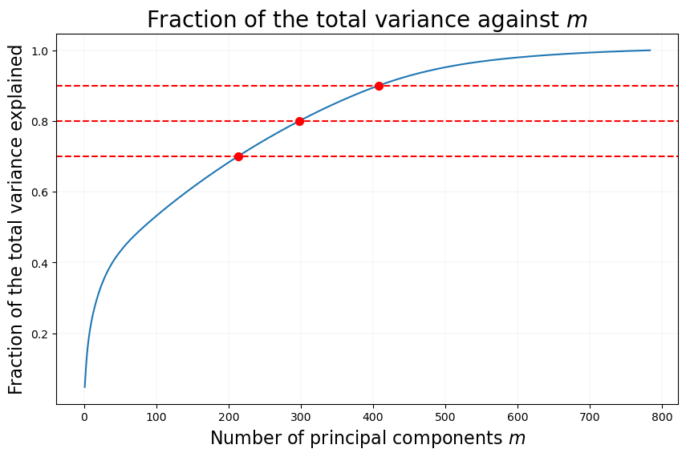

```python
# Set figure size.
plt.figure(figsize=(10, 6))

# Plot the fraction of variance explained against the number of components.
plt.plot(range(1, num_components + 1), pca.explained_variance_cumulative)
# Plot the 70%, 80% and 90% lines and intersections.
plt.axhline(0.7, color='r', linestyle='--')
plt.scatter(
    num_components_70, pca.variance_explained_by(num_components_70),
    marker='o', c='red', s=50, zorder=2
)
plt.axhline(0.8, color='r', linestyle='--')
plt.scatter(
    num_components_80, pca.variance_explained_by(num_components_80),
    marker='o', c='red', s=50, zorder=2
)
plt.axhline(0.9, color='r', linestyle='--')
plt.scatter(
    num_components_90, pca.variance_explained_by(num_components_90),
    marker='o', c='red', s=50, zorder=2
)

# Customize the plot.
plt.grid(visible=True, linewidth=0.1)
plt.title(r'Fraction of the total variance against $m$', fontsize=20)
plt.xlabel(r'Number of principal components $m$', fontsize=16)
plt.ylabel('Fraction of the total variance explained', fontsize=16)
plt.xticks(fontsize=10)
plt.yticks(fontsize=10)

# Show the plot.
plt.show()
```

We visualise the first $m = 10$ principal components from PCA.

```python
# Set the number of principal components.
num_components = 10

# Create the PCA object and fit it to the data.
pca = PCA(num_components=num_components)
pca.fit(noisy_train_data)

# Extract the eigenvalues and eigenvectors.
eigenvalues = pca.eigenvalues
eigenvectors = pca.eigenvectors
```

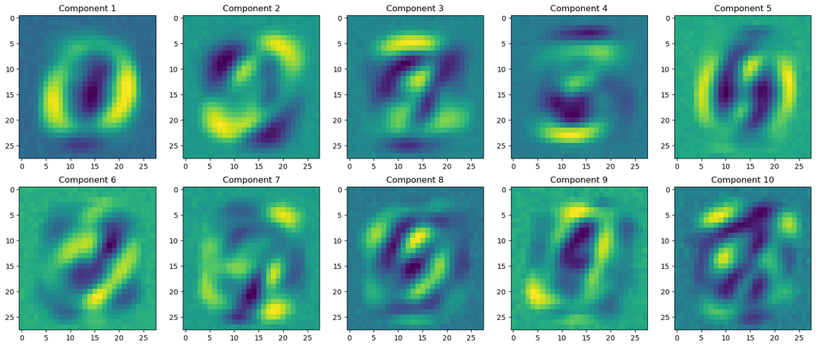

```python
# Set figure size.
fig, axs = plt.subplots(nrows=2, ncols=5, figsize=(20, 8))

# Plot the first m components of the PCA.
for i, ax in enumerate(axs.reshape(-1)):
    ax.imshow(eigenvectors[:, i].reshape([28, 28]), aspect="auto")
    ax.set_title(f"Component {i + 1}")

# Show the plot.
plt.show()
```

In general, PCA captures global features in the data. This is why, if we look closely, the components seems to resemble the characteristics (shapes, curves) of the digits.

#### 1.2.2

We perform dimensionality reduction using NMF, with $m = 10$ dimensions onto which to project the data.

```python
num_iterations = 1000
# Set the number of principal components.
num_components = 10

# Create the NMF object and fit it to the data.
nmf = NMF(num_components=num_components, num_iterations=num_iterations, seed=60012)
scores = nmf.fit(noisy_train_data)

# Extract the W and H components.
W_optim = nmf.W
H_optim = nmf.H
```

Now plot the loss as a function of the number of iterations, in order to show that the chosen number of iterations is sufficient for convergence.

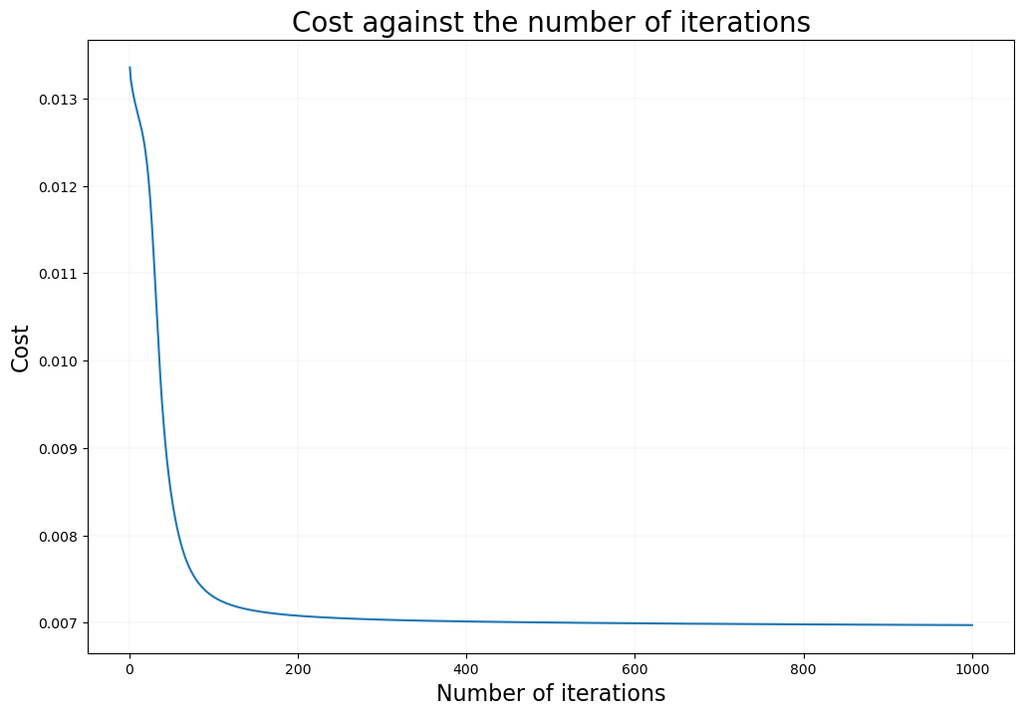

```python
# Set figure size.
plt.figure(figsize=(12, 8))

# Plot the cost against the number of iterations.
plt.plot(range(1, num_iterations + 1), scores)

# Customize the plot.
plt.grid(visible=True, linewidth=0.1)
plt.title(r'Cost against the number of iterations', fontsize=20)
plt.xlabel(r'Number of iterations', fontsize=16)
plt.ylabel('Cost', fontsize=16)
plt.xticks(fontsize=10)
plt.yticks(fontsize=10)

# Show the plot.
plt.show()
```

Visualise the $m = 10$ NMF components.

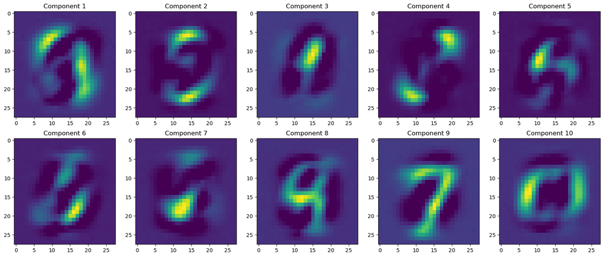

```python
# Set figure size.
fig, axs = plt.subplots(nrows=2, ncols=5, figsize=(20, 8))

# Plot the first m components of the NMF.
for i, ax in enumerate(axs.reshape(-1)):
    ax.imshow(H_optim[i, :].reshape([28, 28]), aspect="auto")
    ax.set_title(f"Component {i + 1}")

# Show the plot.
plt.show()
```

By looking at the plots, we can see that the loss function is decreasing and it seems to have converged.

Now let's have a look at the PCA and NMF components, which seem to be quite different. This is due to the fact that NMF is non-negative, whereas PCA is not.

1. The principal components of PCA are linear combinations of the original features and can be positive or negative. Moreover, they are orthogonal to each other. In general, they capture global features. \ In our case, we can see that they capture overall shape, orientation, thickness and slant of the digits.
2. The components of NMF are non-negative and are not orthogonal to each other. They capture local features and can be interpreted as parts or features of the original data. \ In our case, by looking at the images, we can see that some NMF components capture a pattern of pixels that is strongly correlated with a certain class of digits. They resemble the digits better than the PCA's principal components. This may happen because of several reasons:
   - PCA does not take into account the non-negativity constraint of the pixel values in the MNIST images. Thus, the principal components of PCA can be negative and this can lead to a worse approximation of the original data. Moreover, NMF ensures that the resulting basis vectors and coefficients are also non-negative, which can be more appropriate for data that is inherently non-negative, such as image pixel values.
   - The amount of noise in the data can influence the capacity of each method to capture the features of the data.

Conceptually, it makes sense to use NMF: the MNIST images are non-negative, so it makes sense to model the data with non-negative factors.

#### 1.2.3

We now train PCA and NMF on `MNIST_train_noisy.txt` to find the set of principal components in PCA and non-negative components in NMF, using $m = 100$ principal components for both PCA and NMF.

```python
num_iterations = 1000
num_components = 100

# Create the PCA object and fit it to the data.
pca = PCA(num_components=num_components)
pca.fit(noisy_train_data)

# Create the NMF object and fit it to the data.
nmf = NMF(num_components=num_components, num_iterations=num_iterations, seed=60012)
_ = nmf.fit(noisy_train_data)
```

Using PCA, we can perform image denoising in the following way:

1. Fit the PCA model using the training data in `MNIST_train_noisy.txt`.
2. We scale the data using the mean and std of the training set.

   $$ X \mapsto \frac{X - \mu}{\sigma} \text{ (scale the data)}$$

   where $\mu$ and $\sigma$ are the mean and standard deviation of the training set.
3. We apply the PCA transform of our fitted model on the test data. (i.e. we project the test data on the $m$ principal components of the model)

```
$$ X \mapsto X V \text{ (project the data)}$$

where $V$ is the matrix of the $m$ principal components.
```

1. We apply the PCA inverse transform of our fitted model on the previosly obtained projection.

   $$ X \mapsto X V^T \text{ (move to the original space)}$$
2. We scale the data back (using the mean and std of the traning set) in order to obtain the denoised image.

   $$ X \mapsto X * \sigma + \mu \text{ (rescale the data)}$$

```python
def denoise_PCA(X, pca: PCA):
    """
    Denoise the data X using the PCA.

    Parameters
    ----------
    :param X: {np.ndarray} of shape (num_points, num_features) --
        Data array.
    :param pca: {PCA} --
        PCA object.

    Returns
    ----------
    :rtype: {np.ndarray} of shape (num_points, num_features)
    :return: Data array denoised using the PCA.
    """

    return pca.inverse_transform(
        pca.transform(X)
    )
```

Using NMF, we can perform image denoising in the following way:

1. Fit the NMF model using the training data in `MNIST_train_noisy.txt` (i.e. we find the coefficients of the basis vectors, that is, $H$).
2. We scale the data using min-max of the training set.

   $$ X \mapsto \frac{X - \min}{\max - \min} \text{ (scale the data)}$$

   where $\min$ and $\max$ are the min and max of the training set.
3. We apply the NMF transform of our fitted model on the test data. (i.e. we find the basis vectors that best approximate the test data)

   By keeping $H$ (the matrix of coefficients) fixed, we find the new $W$ (the matrix of basis vectors) with the same procedure as in the training of the network.

   $$ X \mapsto W_{\text{new}} \text{ (transform)}$$

   where $W_{\text{new}}$ is the new matrix of the basis vectors.
1. We apply the NMF inverse transform of our fitted model on the previosly obtained projection (i.e. we multiply the coefficients by the basis vectors).

   $$ X \mapsto X H \text{ (inverse transform)}$$

   where $H$ is the matrix of the coefficients.
2. We scale the data back (using the min and max of the training set) in order to obtain the denoised image.

   $$ X \mapsto X * (\max - \min) + \min \text{ (rescale the data)}$$

```python
def denoise_NMF(X, nmf: NMF):
    """
    Denoise the data X using the NMF.

    Parameters
    ----------
    :param X: {np.ndarray} of shape (num_points, num_features) --
        Data array.
    :param nmf: {NMF} --
        NMF object.

    Returns
    ----------
    :rtype: {np.ndarray} of shape (num_points, num_features)
    :return: Data array denoised using the NMF.
    """

    return nmf.inverse_transform(
        nmf.transform(X)
    )
```

We now denoise all the images in `MNIST_test_noisy.txt` using PCA and NMF.

```python
# Denoise the test images using PCA.
denoised_test_pca = denoise_PCA(noisy_test_data, pca)
```

```python
# Denoise the test images using NMF.
denoised_test_nmf = denoise_NMF(noisy_test_data, nmf)
```

We pick an image from the noisy test set and visualise it along with its original version (from `MNIST_test.csv`) and its reconstructed version by both PCA and NMF with $m = 100$ principal components.

```python
# Pick an image from the test set.
test_image_index = 50
```

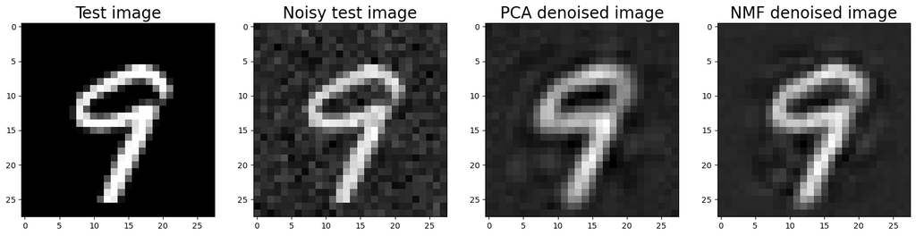

```python
# Set figure size.
fig, axs = plt.subplots(nrows=1, ncols=4, figsize=(20, 8))

# Plot the original image.
axs[0].imshow(test_data[test_image_index].reshape(mnist_image_shape), cmap='gray')
# Customize the plot.
axs[0].set_title('Test image', fontsize=20)

# Plot the noisy image.
axs[1].imshow(noisy_test_data[test_image_index].reshape(mnist_image_shape), cmap='gray')
# Customize the plot.
axs[1].set_title('Noisy test image', fontsize=20)

# Plot the PCA denoised image.
axs[2].imshow(denoised_test_pca[test_image_index].reshape(mnist_image_shape), cmap='gray')
# Customize the plot.
axs[2].set_title('PCA denoised image', fontsize=20)

# Plot the NMF denoised image.
axs[3].imshow(denoised_test_nmf[test_image_index].reshape(mnist_image_shape), cmap='gray')
# Customize the plot.
axs[3].set_title('NMF denoised image', fontsize=20)

# Show the plot.
plt.show()
```

1. PCA removes the noise by projecting the image onto a lower-dimensional space, and then reconstructing the image from the projection.
2. NMF removes the noise by factorizing the image into a set of basis images and coefficients. The underlying patterns in the image are captured by the basis vectors, while the contribution of each basis image is captured by the coefficients.

By looking at the plot, we can see that both models have a good performance, being able to reconstruct the image. However, we notice that NMF is able to remove the noise better than PCA. This may be due to the following:

- PCA does not take in account the non-negativity property or our data. Because of this, it is not able to remove the noise as well as $NMF$.
- PCA captures global features, while NMF captures local features. This may be the reason why NMF is able to remove the noise better than PCA.

#### 1.2.4

Compute the Mean-Squared Error (MSE) between the reconstructed images and

1. the test set of uncorrupted images (`MNIST_test.csv`).
2. the test set of noise-corrupted images (`MNIST_test_noisy.txt`).

We then plot, on the same figure, these two MSEs as a function of the number of PCA components $m$, varying $m$ in the interval $5 - 400$ with a step size of $5$.

```python
def mse(y_true, y_pred):
    """
    Compute the mean squared error between the true and predicted values.

    Parameters
    ----------
    :param y_true: {np.ndarray} of shape (num_points, num_features) --
        True values.
    :param y_pred: {np.ndarray} of shape (num_points, num_features) --
        Predicted values.

    Returns
    ----------
    :rtype: {float}
    :return: Mean squared error.
    """

    return np.mean((y_true - y_pred) ** 2)
```

```python
# Define the range of m (number of components) as above.
m_range = np.arange(5, 405, 5)

seed = 60012

MSE_uncorrupted = []
MSE_corrupted = []

for m in m_range:
    # Create the PCA object and fit it to the data.
    pca = PCA(num_components=m)
    pca.fit(noisy_train_data)

    # Denoise the test images using PCA.
    denoised_test_images = denoise_PCA(noisy_test_data, pca)

    # Compute the MSE.
    MSE_uncorrupted.append(mse(test_data, denoised_test_images))
    MSE_corrupted.append(mse(noisy_test_data, denoised_test_images))
```

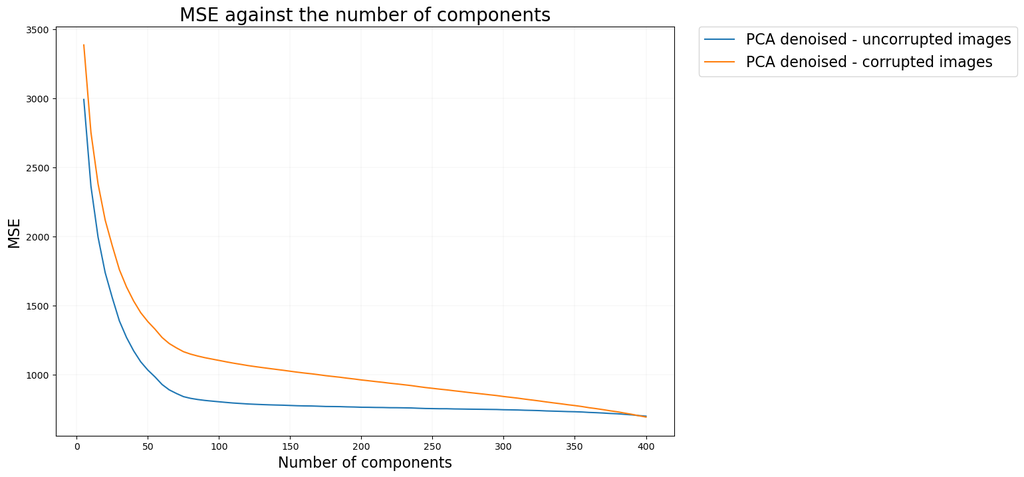

```python
# Set figure size.
plt.figure(figsize=(12, 8))

# Plot the MSE against the number of components.
plt.plot(m_range, MSE_uncorrupted, label='PCA denoised - uncorrupted images')
plt.plot(m_range, MSE_corrupted, label='PCA denoised - corrupted images')

# Customize the plot.
plt.grid(visible=True, linewidth=0.1)
plt.title('MSE against the number of components', fontsize=20)
plt.xlabel('Number of components', fontsize=16)
plt.ylabel('MSE', fontsize=16)
plt.xticks(fontsize=10)
plt.yticks(fontsize=10)
plt.legend(
    bbox_to_anchor=(1.04, 1),
    borderaxespad=0,
    loc="upper left",
    fontsize=16,
)

# Show the plot.
plt.show()
```

We visualise an example of a reconstructed image for $m \in \{ 10, 40, 100, 200 \}$.

```python
# Pick an image from the test set.
test_image_index = 50
```

```python
num_iterations = 1000  # number of iterations for NMF

m_range = [10, 40, 100, 200]  # range for number of components

seed = 60012

denoised_test_image_pca = []
denoised_test_image_nmf = []

for m in m_range:
    # Create the PCA object and fit it to the data.
    pca = PCA(num_components=m)
    pca.fit(noisy_train_data)

    # Create the NMF object and fit it to the data.
    nmf = NMF(num_components=m, num_iterations=num_iterations, seed=seed)
    nmf.fit(noisy_train_data)

    # Denoise the test image using PCA.
    denoised_test_image_pca.append(
        denoise_PCA(noisy_test_data[test_image_index], pca)
    )

    # Denoise the test image using NMF.
    denoised_test_image_nmf.append(
        denoise_NMF(noisy_test_data[test_image_index], nmf)
    )
```

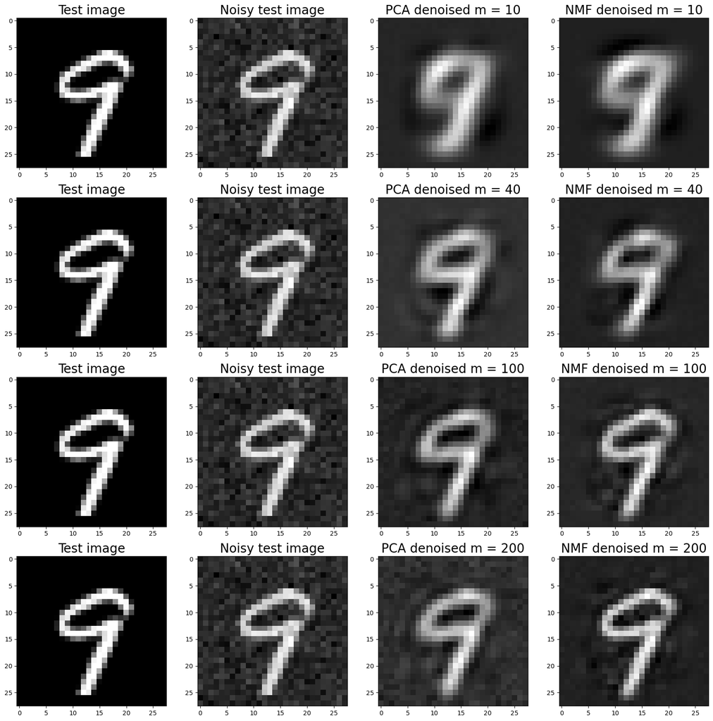

```python
# Set figure size.
fig, axs = plt.subplots(nrows=len(m_range), ncols=4, figsize=(20, 20))

# Plot the denoised images for each m.
for index, m in enumerate(m_range):
    # Plot the original image.
    axs[index][0].imshow(test_data[test_image_index].reshape(mnist_image_shape), cmap='gray')
    # Customize the plot.
    axs[index][0].set_title('Test image', fontsize=20)

    # Plot the noisy image.
    axs[index][1].imshow(noisy_test_data[test_image_index].reshape(mnist_image_shape), cmap='gray')
    # Customize the plot.
    axs[index][1].set_title('Noisy test image', fontsize=20)

    # Plot the PCA denoised image.
    axs[index][2].imshow(denoised_test_image_pca[index].reshape(mnist_image_shape), cmap='gray')
    # Customize the plot.
    axs[index][2].set_title(f'PCA denoised m = {m}', fontsize=20)

    # Plot the NMF denoised image.
    axs[index][3].imshow(denoised_test_image_nmf[index].reshape(mnist_image_shape), cmap='gray')
    # Customize the plot.
    axs[index][3].set_title(f'NMF denoised m = {m}', fontsize=20)

# Show the plot.
plt.show()
```

1. Let's look at the PCA denoised images. As the value of $m$ increases, we observe an increasing amount of noise, causing the denoised images to bear a closer resemblance to the noisy versions rather than the original images. This is in line with the MSE plot we made before: as the number of principal components increases, both MSEs decrease. But at some point, the MSE w.r.t. the original images remains almost constant, while the MSE w.r.t. the noisy images decreases. This is because the model starts to overfit and capture the noise of the data.

   Here we have a trade-off between the number of principal components and the amount of noise. If we use too few principal components, we will not be able to reconstruct the image well. If we use too many principal components, we will be able to reconstruct the image well, but we will also capture the noise.
2. Let's look at the NMF denoised images. For low $m$, we don't capture the properties of the data too well, but if we increase it, we start to model the data better. However, we notice that the noise is still present, but not that much compared to PCA.

Both algorithms are performing well at reconstructing the image, but the NMF seems to be better since it doesn't capture that much noise.

### 1.3 Gaussian Mixture Models (20 marks)

**GMM** (**Gaussian Mixture Model**) is a statistical model used for probability distribution estimation. It assumes that the data is generated from a mixture of several Gaussian distributions, each with its own mean and variance. The model estimates the parameters of these Gaussians, as well as the mixing coefficients that determine the probability of each Gaussian generating a data point.

In order to estimate the parameters of a GMM, we're going to use **EM** (or **Expectation-Maximization**). It consists of two steps, the E-step and the M-step, which are repeated iteratively until convergence.

In the E-step, the algorithm computes the expected values of the cluster assignments, for each data point. This is done using Bayes' rule and the current estimates of the GMM parameters.

In the M-step, the algorithm updates the estimates of the GMM parameters based on the expected values computed in the E-step. This involves maximizing the log-likelihood of the data with respect to the mean, covariance, and mixing coefficients of the Gaussian distributions.

By alternating between these two steps, the algorithm iteratively refines the estimates of the GMM parameters until convergence is reached.

#### 1.3.0 GMM

- We start with the definition of a Gaussian Mixture Model (GMM):

  $$ P(X = x) = \sum_{k = 1}^K \pi_k p_k(x \mid \theta) $$

  Here $K$ is the number of clusters described as mixture components, each of which are multivariate normal distributions:

  $$ p_k(x \mid \theta) =

  ```
    (2 \pi)^{- k / 2}
    \det({\Sigma}_k)^{- 1 / 2}
    \exp \left(- {\frac{1}{2}} (x - {\mu}_k)^T  {\Sigma}_k^{-1} (x - {\mu}_k) \right)
  ```

  $$

  where $\theta = \{ \pi_k, \mu_k, \Sigma_k \}_{k = 1, 2, \ldots, K}$ is the vectors of parameters consiting of
  1. the mixture weight $\pi_k$,
  2. mixture component mean ${\mu}_k$,
  3. mixture component covariance matrix ${\Sigma}_k$.
- We can perform *soft* clustering of the data using the cluster probabilities of the data:

  $$ r_{ik}(\theta)

  ```
    = P(Z=k \mid X=x_i, \theta)
    = \frac{\pi_k p_k(x_i \mid \theta)}{\sum_{k'=1}^K \pi_{k'} p_{k'}(x_i \mid \theta)}
  ```

  $$

  This denotes the probability of data point $i$ to belong to cluster $k$. Generally, this yields a distribution over each data point.
- For *hard* clustering, we can assign each data point to the cluster with the highest probability:

$$ z_i = \operatorname{argmax}_{k} r_{ik}(\theta) $$

- We employ the EM algorithm to fit the data. The algorithm iteratively updates parameters of the Gausian Mixture. The algorithm is guarantees to improve (or at least not worsen) the marginal likelihood of the data. The algorithm updates the mixture weights:

  $$

  ```
    \pi_k^{(n+1)} = \frac{1}{N} \sum_{i=1}^N r_{ik}(\theta^{(n)}),
  ```

  $$

  and computes the cluster means using a weighted mean:

  $$ \mu_k^{(n+1)} = \sum_{i=1}^N w_{ik}(\theta^{(n)}) x_i $$

  and similarly for the covariances according to:

  $$ \Sigma_k^{(n+1)}= \sum_{i=1}^N w_{ik}(\theta^{(n)}) (x_i - \mu_k) (x_i - \mu_k)^T $$

  The weights are obtained from the cluster probabilities via $$ w_{ik}(\theta^{(n)}) = \frac{r_{ik} (\theta^{(n)})}{\sum_{i'} r_{i'k}(\theta^{(n)})} $$

```python
class GMM:
    """
    Gaussian Mixture Model

    Attributes
    ----------
    :attr num_components: {int} --
        Number of mixture components.

    :attr num_iterations: {int} --
        Number of iterations to run the EM algorithm for.

    :attr tol: {float} --
        Tolerance for the EM algorithm.

    :attr seed: {int} --
        Seed for the random number generator.

    :attr converged: {bool} --
        Whether the model has converged.

    :attr phi: {np.ndarray} of shape (num_points, num_components) --
        Mixture weights.

    :attr mu: {np.ndarray} of shape (dim, num_features) --
        Mixture component means for each cluster.

    :attr sigma: {np.ndarray} of shape (dim, num_features, num_features) --
        Mixture component covariance matrix for each cluster.
    """

    def __init__(
            self,
            num_components=1,
            num_iterations=100,
            tol=1e-3,
            seed=None,
    ):
        """
        Initialises parameters through random split of the data.

        Parameters
        ----------
        :param num_components: {int} --
            Number of mixture components.
        :param num_iterations: {int} --
            Number of iterations to run the EM algorithm for.
        :param tol: {float} --
            Tolerance for the EM algorithm.
        :param seed: {int} --
            Seed for the random number generator.
        """

        self.num_components = num_components
        self.num_iterations = num_iterations
        self.tol = tol

        self.seed = seed

    def fit(self, X):
        """
        Fits the model to the data.

        Parameters
        ----------
        :param X: {np.ndarray} of shape (num_points, num_features) --
            Dataset to fit the model to.
        """

        # Initialises parameters.
        self._init_params(X)

        # Perform EM algorithm.
        for _ in range(self.num_iterations):
            # Store previous values.
            prev_mu = self.mu.copy()
            prev_sigma = self.sigma.copy()
            prev_phi = self.phi.copy()

            # Perform EM step.
            self._fit_step(X)

            # Check pointwise convergence.
            mu_converged = np.all(np.abs(self.mu - prev_mu) < self.tol)
            sigma_converged = np.all(np.abs(self.sigma - prev_sigma) < self.tol)
            phi_converged = np.all(np.abs(self.phi - prev_phi) < self.tol)
            if mu_converged and sigma_converged and phi_converged:
                self.converged = True
                return

        self.converged = False

    def predict_proba(self, X):
        """
        Performs soft clustering (i.e. predicts probability of each data point with respect to each cluster).

        Parameters
        ----------
        :param X: {np.ndarray} of shape (num_points, num_features) --
            Dataset to predict the probabilities for.

        Returns
        -------
        :rtype: {np.ndarray} of shape (num_points, num_clusters)
        :return: Predicted probabilities of each data point with respect to each cluster.
        """

        num_samples = X.shape[0]

        # Creates a (num_samples)x(num_clusters) matrix denoting likelihood belonging to each cluster.
        likelihood = np.zeros((num_samples, self.num_components))
        for i in range(self.num_components):
            # Likelihood of data belonging to i-th cluster.
            distribution = multivariate_normal(mean=self.mu[i], cov=self.sigma[i])
            likelihood[:, i] = distribution.pdf(X)

            # Compute the weights for each data point wrt to each cluster.
            numerator = likelihood * self.phi
            denominator = numerator.sum(axis=1)[:, np.newaxis]
            weights = numerator / denominator

        return weights

    def predict(self, X):
        """
        Performs hard clustering (i.e. predicts a cluster for each data point).

        Parameters
        ----------
        :param X: {np.ndarray} of shape (num_points, num_features) --
            Dataset to predict the clusters for.

        Returns
        -------
        :rtype: {np.ndarray} of shape (num_points, )
        :return: Predicted clusters for each data point.
        """

        weights = self.predict_proba(X)

        return np.argmax(weights, axis=1)

    def _init_params(self, X):
        """
        Initialises parameters through random split of the data.

        Parameters
        ----------
        :param X: {np.ndarray} of shape (num_points, num_features) --
            Dataset to fit the model to.
        """

        num_samples = X.shape[0]

        # Initial weights given to each cluster are stored in phi or P(Ci=j).
        self.phi = np.full(shape=self.num_components, fill_value=1 / self.num_components)

        # Dataset is divided randomly into {num_components} parts of unequal sizes.
        rng = np.random.default_rng(self.seed)
        random_row = rng.choice(num_samples, size=self.num_components, replace=False)
        # Initial value of mean of {num_components} Gaussians.
        self.mu = np.array([X[row_index, :] for row_index in random_row])

        # Initial value of covariance matrix of {num_components} Gaussians.
        self.sigma = np.array([np.cov(X.T) for _ in range(self.num_components)])

    def _fit_step(self, X):
        """
        Performs an EM step by updating all parameters.

        Parameters
        ----------
        :param X: {np.ndarray} of shape (num_points, num_features) --
            Dataset to fit the model to.
        """

        # E-Step: Update weights and phi holding mu and sigma constant.
        weights = self.predict_proba(X)
        self.phi = weights.mean(axis=0)

        # M-Step: Update mu and sigma holding pi and weights constant.
        for i in range(self.num_components):
            weight = weights[:, [i]]
            total_weight = weight.sum()

            self.mu[i] = np.sum(X * weight, axis=0) / total_weight
            self.sigma[i] = np.cov(
                X.T,
                aweights=(weight / total_weight).flatten(),
                bias=True
            )
```

#### 1.3.1

We get the first $5$ principal components on the first $N = 1000$ photos from `MNIST_train.csv`.

```python
num_photos = 1000

# Get the data and labels.
X_gmm = train_data[: num_photos]
y_gmm = train_labels[: num_photos]
```

```python
num_components = 5

# Create the PCA object and fit it to the data.
pca = PCA(num_components=num_components)
pca.fit(X_gmm)

# Get the PCA version of the training set.
pca_X_gmm = pca.transform(X_gmm)
```

We perform clustering using a GMM model with $10$ hidden components and compute the predictions on the PCA version of the training set.

```python
# Parameters for GMM model.
num_components = 10
num_iterations = 1000
tol = 1e-3
seed = 60012

# Create the GMM object and fit it to the data.
gmm = GMM(
    num_components=num_components,
    num_iterations=num_iterations,
    tol=tol,
    seed=seed
)
gmm.fit(pca_X_gmm)

# Make predictions on the training set.
clusters = gmm.predict(pca_X_gmm)

print(f"GMM has converged: {gmm.converged}")
```

```
GMM has converged: True
```

Display the principal component 2 against principal component 1. We color the points according to the predicted cluster.

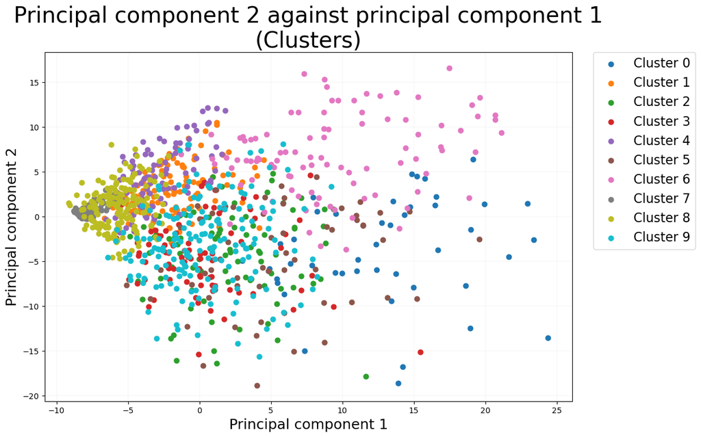

```python
# Set the size of the figure
plt.figure(figsize=(12, 8))

# Plot the GMM predictions.
for cluster in np.unique(clusters):
    plt.scatter(
        pca_X_gmm[clusters == cluster, 0],
        pca_X_gmm[clusters == cluster, 1],
        s=40, zorder=2,
        label=f"Cluster {cluster}"
    )

# Customize the plot.
plt.grid(visible=True, linewidth=0.1)
plt.title('Principal component 2 against principal component 1\n(Clusters)', fontsize=28)
plt.xlabel('Principal component 1', fontsize=18)
plt.ylabel('Principal component 2', fontsize=18)
plt.legend(
    bbox_to_anchor=(1.04, 1),
    borderaxespad=0,
    loc="upper left",
    fontsize=16,
)

plt.show()
```

#### 1.3.2

We use the class labels to visualise the space spanned by the top two principal components.

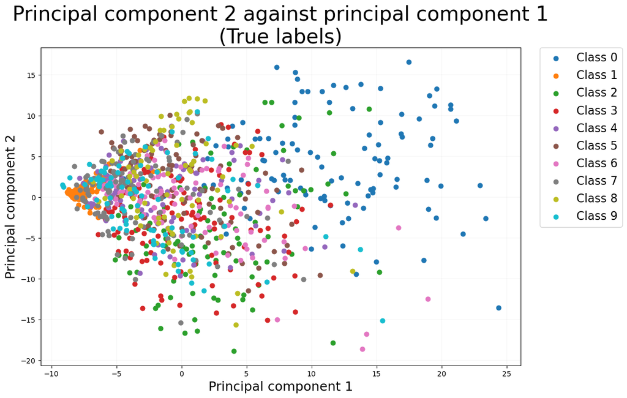

```python
# Set the size of the figure
plt.figure(figsize=(12, 8))

# Plot the true labels.
for label in np.unique(y_gmm):
    plt.scatter(
        pca_X_gmm[y_gmm == label, 0],
        pca_X_gmm[y_gmm == label, 1],
        s=40, zorder=2,
        label=f"Class {label}"
    )

# Customize the plot.
plt.grid(visible=True, linewidth=0.1)
plt.title('Principal component 2 against principal component 1\n(True labels)', fontsize=28)
plt.xlabel('Principal component 1', fontsize=18)
plt.ylabel('Principal component 2', fontsize=18)
plt.legend(
    bbox_to_anchor=(1.04, 1),
    borderaxespad=0,
    loc="upper left",
    fontsize=16,
)

# Show the plot.
plt.show()
```

We now map the class labels to the best-fitting cluster index. To achieve this, we use the log-likelihood of each mixture component evaluated at the images in each class to measure the fit quality. We then assign the class label to the cluster with the highest log-likelihood.

```python
def get_label_cluster_assignments(gmm: GMM, X, y):
    """
    Gets the class-cluster assignments for the GMM model.

    Parameters
    ----------
    :param gmm: {GMM} --
        GMM model.
    :param X: {np.ndarray} of shape (num_points, num_features) --
        Input dataset
    :param y: {np.ndarray} of shape (num_points, ) --
        True classes for the dataset.

    Returns
    -------
    :rtype: {np.ndarray} of shape (num_classes, )
    :return: Class-cluster assignments.
    """

    num_samples = X.shape[0]
    num_classes = np.unique(y).shape[0]

    # Initialise the log-likelihood array.
    log_likelihood = np.zeros((num_samples, gmm.num_components))

    # Compute the likelihood of the data belonging to each cluster j.
    for j in range(gmm.num_components):
        log_likelihood[:, j] = multivariate_normal(mean=gmm.mu[j], cov=gmm.sigma[j]).logpdf(X)

    # Initialise the probability array of labels belonging to each cluster.
    prob_label = np.zeros((num_classes, gmm.num_components))

    # Get the probabilities for each label i.
    for i in range(num_classes):
        prob_label[i, :] = log_likelihood[(y == i)].sum(axis=0)

    # Get the class-cluster assignments.
    label_cluster_map = np.argmax(prob_label, axis=1)

    return label_cluster_map
```

```python
# Map the class labels to the best matching cluster.
label_cluster_map = get_label_cluster_assignments(gmm, pca_X_gmm, y_gmm)

# Get the number of classes.
num_classes = np.unique(y_gmm).shape[0]
```

```python
# Visualise the class-cluster assignments.
df = pd.DataFrame(
    [[i, label_cluster_map[i]] for i in range(num_classes)],
    columns=["Label", "Corresponding cluster"],
)

# Customize the visualisation.
styler = df.style
styler = styler.hide(axis='index')
styler = styler.set_properties(**{'text-align': 'center'})

styler
```

| Label | Corresponding cluster |
| --- | --- |
| 0 | 6 |
| 1 | 7 |
| 2 | 5 |
| 3 | 9 |
| 4 | 3 |
| 5 | 9 |
| 6 | 2 |
| 7 | 9 |
| 8 | 9 |
| 9 | 3 |

By looking at the $2$ plots, we see that we should be able to cluster the classes. But the class-cluster mapping is not injective (i.e. some classes are mapped to the same clusters) and many clusters are not used at all. \ This is an indication our clustering is not representative of the data, which might be due to the PCA model with $5$ components not being able to capture the structure of the data well enough. Five components might not be enough to capture the variance of the data, especially since we want to group the data into $10$ clusters.

#### 1.3.3

Now we use the label-cluster index map to compute the cluster probabilities for each digit.

```python
def cluster_probabilities(X, y, gmm, label_cluster_map):
    """
    Computes the probability of the data belonging to the cluster.

    Parameters
    ----------
    :param X: {np.ndarray} of shape (num_points, num_features) --
        Input dataset
    :param y: {np.ndarray} of shape (num_points, ) --
        True classes for the dataset.
    :param gmm: {GMM} --
        GMM model.
    :param label_cluster_map: {np.ndarray} of shape (num_classes, ) --
        Class-cluster assignments.

    Returns
    -------
    :rtype: {list}, {list}
    :return: List of data belonging to each class and the corresponding probabilities.
    """

    data_array = []
    prob_array = []

    for label in y:
        # Get the corresponding cluster.
        cluster = label_cluster_map[label]

        # Get the corresponding training data of this label.
        X_label = X[(y == label)]

        # Compute the probability of the data belonging to the cluster.
        prob_label = gmm.predict_proba(X_label)[:, cluster]

        # Store the data and probabilities.
        data_array.append(X_label)
        prob_array.append(prob_label)

    return data_array, prob_array
```

```python
# Get the cluster probabilities for each digit.
data_array, prob_array = cluster_probabilities(pca_X_gmm, y_gmm, gmm, label_cluster_map)

num_labels = len(np.unique(y_gmm))
```

For each class, we visualise the space spanned by the top two components by colouring each point according to the cluster probability of the best-fitting cluster.

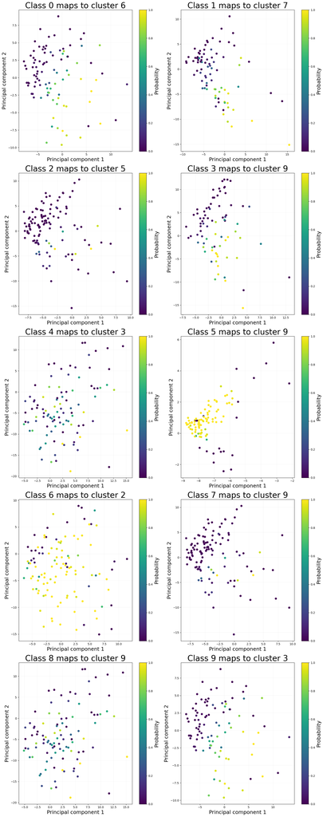

```python
# Set the size of the figure.
fig, axs = plt.subplots(nrows=5, ncols=2, figsize=(16, 40))

for i in range(num_labels):
    # Get the ax.
    ax = axs[i // 2, i % 2]

    # Get the data and probabilities.
    data = data_array[i]
    prob = prob_array[i]

    # Plot the GMM predictions.
    sc = ax.scatter(
        data[:, 0], data[:, 1],
        c=prob, s=40, cmap='viridis', zorder=2,
        vmax=1, vmin=0
    )

    # Customize the plot.
    ax.grid(visible=True, linewidth=0.1)
    ax.set_title(f'Class {i} maps to cluster {label_cluster_map[i]}', fontsize=28)
    ax.set_xlabel('Principal component 1', fontsize=18)
    ax.set_ylabel('Principal component 2', fontsize=18)

    # Add the colorbar.
    cbar = plt.colorbar(sc, ax=ax)
    cbar.set_label("Probability", fontsize=18)

# Show the plot.
plt.tight_layout()
plt.show()
```

By looking at the plots, we see that the probabilities of the best-fitting cluster are pretty small for almost all points in the respective class (with $1 - 2$ exceptions). This means that the cluster is not a good fit for the class. \ Also, notice that not all of the clusters are used.

These low probabilities are another indication that our clustering is not representative of the data. This might be due to the PCA model with $5$ components not being able to explain the variance of the data well enough. Five components might not be enough to capture the structure of the data, especially since we want to group the data into $10$ clusters.

#### 1.3.4

We perform clustering using a GMM model with $8$ hidden components and compute the predictions on the PCA version of the training set.

```python
# Parameters for GMM model.
num_components = 8
num_iterations = 1000
tol = 1e-3
seed = 60012

# Create the GMM object and fit it to the data.
gmm = GMM(
    num_components=num_components,
    num_iterations=num_iterations,
    tol=tol,
    seed=seed
)
gmm.fit(pca_X_gmm)

# Make predictions on the training set.
clusters = gmm.predict(pca_X_gmm)

print(f"GMM has converged: {gmm.converged}")
```

```
GMM has converged: True
```

Display the principal component $2$ against principal component $1$. We color the points according to the predicted cluster.

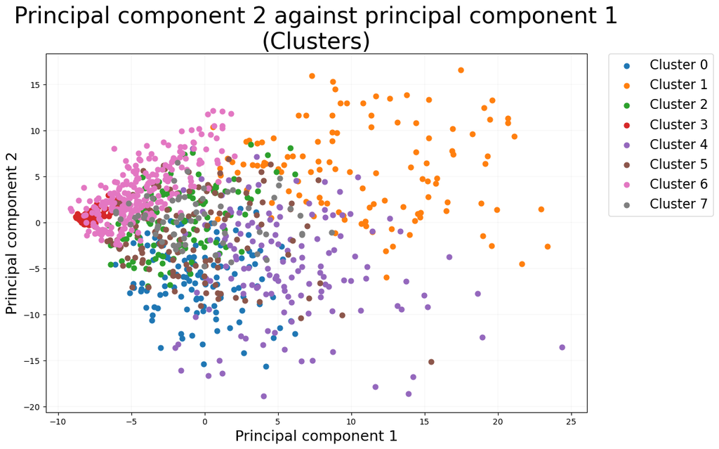

```python
# Set the size of the figure
plt.figure(figsize=(12, 8))

# Plot the GMM predictions.
for cluster in np.unique(clusters):
    plt.scatter(
        pca_X_gmm[clusters == cluster, 0],
        pca_X_gmm[clusters == cluster, 1],
        s=40, zorder=2,
        label=f"Cluster {cluster}"
    )

# Customize the plot.
plt.grid(visible=True, linewidth=0.1)
plt.title('Principal component 2 against principal component 1\n(Clusters)', fontsize=28)
plt.xlabel('Principal component 1', fontsize=18)
plt.ylabel('Principal component 2', fontsize=18)
plt.legend(
    bbox_to_anchor=(1.04, 1),
    borderaxespad=0,
    loc="upper left",
    fontsize=16,
)

plt.show()
```

We now map the class labels to the best-fitting cluster index.

```python
# Map the class labels to the best matching cluster.
label_cluster_map = get_label_cluster_assignments(gmm, pca_X_gmm, y_gmm)

# Get the number of classes.
num_classes = np.unique(y_gmm).shape[0]
```

```python
# Visualise the class-cluster assignments.
df = pd.DataFrame(
    [[i, label_cluster_map[i]] for i in range(num_classes)],
    columns=["Label", "Corresponding cluster"],
)

# Customize the visualisation.
styler = df.style
styler = styler.hide(axis='index')
styler = styler.set_properties(**{'text-align': 'center'})

styler
```

| Label | Corresponding cluster |
| --- | --- |
| 0 | 1 |
| 1 | 3 |
| 2 | 4 |
| 3 | 4 |
| 4 | 5 |
| 5 | 4 |
| 6 | 4 |
| 7 | 5 |
| 8 | 4 |
| 9 | 5 |

For each class, we visualise the space spanned by the top two components by colouring each point according to the cluster probability of the best-fitting cluster.

```python
# Get the cluster probabilities for each digit.
data_array, prob_array = cluster_probabilities(pca_X_gmm, y_gmm, gmm, label_cluster_map)

num_labels = len(np.unique(y_gmm))
```

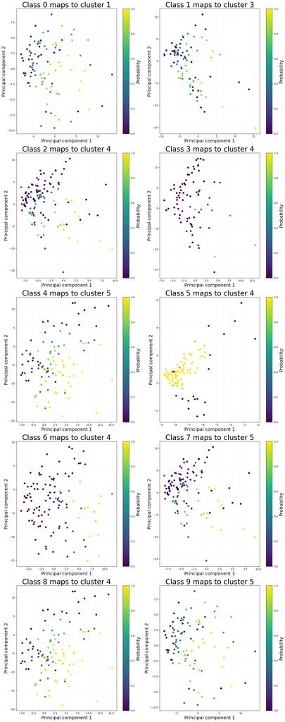

```python
# Set the size of the figure.
fig, axs = plt.subplots(nrows=5, ncols=2, figsize=(16, 40))

for i in range(num_labels):
    # Get the ax.
    ax = axs[i // 2, i % 2]

    # Get the data and probabilities.
    data = data_array[i]
    prob = prob_array[i]

    # Plot the GMM predictions.
    sc = ax.scatter(
        data[:, 0], data[:, 1],
        c=prob, s=40, cmap='viridis', zorder=2,
        vmax=1, vmin=0
    )

    # Customize the plot.
    ax.grid(visible=True, linewidth=0.1)
    ax.set_title(f'Class {i} maps to cluster {label_cluster_map[i]}', fontsize=28)
    ax.set_xlabel('Principal component 1', fontsize=18)
    ax.set_ylabel('Principal component 2', fontsize=18)

    # Add the colorbar.
    cbar = plt.colorbar(sc, ax=ax)
    cbar.set_label("Probability", fontsize=18)

# Show the plot.
plt.tight_layout()
plt.show()
```

We perform clustering using a GMM model with $5$ hidden components and compute the predictions on the PCA version of the training set.

```python
# Parameters for GMM model.
num_components = 5
num_iterations = 1000
tol = 1e-3
seed = 60012

# Create the GMM object and fit it to the data.
gmm = GMM(
    num_components=num_components,
    num_iterations=num_iterations,
    tol=tol,
    seed=seed
)
gmm.fit(pca_X_gmm)

# Make predictions on the training set.
clusters = gmm.predict(pca_X_gmm)

print(f"GMM has converged: {gmm.converged}")
```

```
GMM has converged: True
```

Display the principal component $2$ against principal component $1$. We color the points according to the predicted cluster.

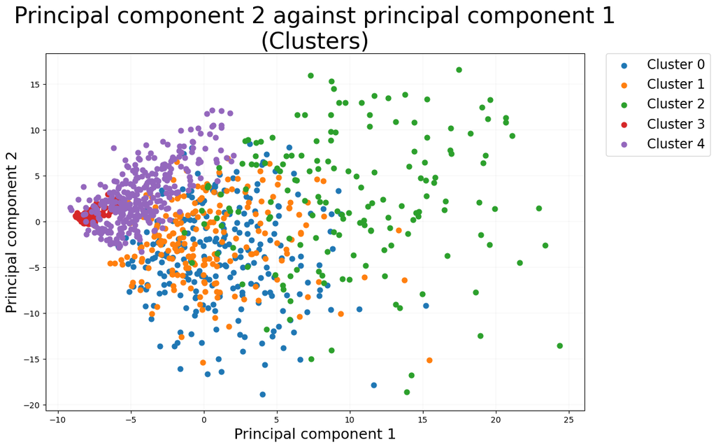

```python
# Set the size of the figure
plt.figure(figsize=(12, 8))

# Plot the GMM predictions.
for cluster in np.unique(clusters):
    plt.scatter(
        pca_X_gmm[clusters == cluster, 0],
        pca_X_gmm[clusters == cluster, 1],
        s=40, zorder=2,
        label=f"Cluster {cluster}"
    )

# Customize the plot.
plt.grid(visible=True, linewidth=0.1)
plt.title('Principal component 2 against principal component 1\n(Clusters)', fontsize=28)
plt.xlabel('Principal component 1', fontsize=18)
plt.ylabel('Principal component 2', fontsize=18)
plt.legend(
    bbox_to_anchor=(1.04, 1),
    borderaxespad=0,
    loc="upper left",
    fontsize=16,
)

plt.show()
```

We now map the class labels to the best-fitting cluster index.

```python
# Map the class labels to the best matching cluster.
label_cluster_map = get_label_cluster_assignments(gmm, pca_X_gmm, y_gmm)

# Get the number of classes.
num_classes = np.unique(y_gmm).shape[0]
```

```python
# Visualise the class-cluster assignments.
df = pd.DataFrame(
    [[i, label_cluster_map[i]] for i in range(num_classes)],
    columns=["Label", "Corresponding cluster"],
)

# Customize the visualisation.
styler = df.style
styler = styler.hide(axis='index')
styler = styler.set_properties(**{'text-align': 'center'})

styler
```

| Label | Corresponding cluster |
| --- | --- |
| 0 | 2 |
| 1 | 3 |
| 2 | 0 |
| 3 | 0 |
| 4 | 1 |
| 5 | 2 |
| 6 | 1 |
| 7 | 1 |
| 8 | 2 |
| 9 | 1 |

For each class, we visualise the space spanned by the top two components by colouring each point according to the cluster probability of the best-fitting cluster.

```python
# Get the cluster probabilities for each digit.
data_array, prob_array = cluster_probabilities(pca_X_gmm, y_gmm, gmm, label_cluster_map)

num_labels = len(np.unique(y_gmm))
```

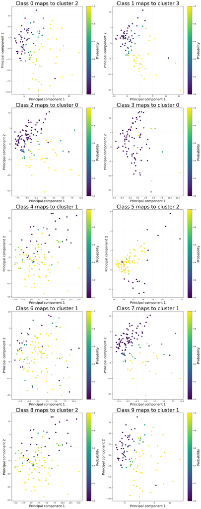

```python
# Set the size of the figure.
fig, axs = plt.subplots(nrows=5, ncols=2, figsize=(16, 40))

for i in range(num_labels):
    # Get the ax.
    ax = axs[i // 2, i % 2]

    # Get the data and probabilities.
    data = data_array[i]
    prob = prob_array[i]

    # Plot the GMM predictions.
    sc = ax.scatter(
        data[:, 0], data[:, 1],
        c=prob, s=40, cmap='viridis', zorder=2,
        vmax=1, vmin=0
    )

    # Customize the plot.
    ax.grid(visible=True, linewidth=0.1)
    ax.set_title(f'Class {i} maps to cluster {label_cluster_map[i]}', fontsize=28)
    ax.set_xlabel('Principal component 1', fontsize=18)
    ax.set_ylabel('Principal component 2', fontsize=18)

    # Add the colorbar.
    cbar = plt.colorbar(sc, ax=ax)
    cbar.set_label("Probability", fontsize=18)

# Show the plot.
plt.tight_layout()
plt.show()
```

We compare these results to the 10 component results (tasks 1.3.2 and 1.3.3).

By looking at the probability plots, we notice that as we decrease the number of components, the clusters become more representative of the data. This is surprising since the number of true classes is $10$. We would expect that the optimal number of components should be at least equal to the number of true classes, but that's not the case here.

This is because the data is projected onto $5$ principal components. As previosly mentioned, the PCA model with $5$ components might not be able to capture the structure of the data well enough. Five components might not be enough to capture the variance of the data, especially since we want to group the data into $10$ clusters. Hence decreasing the number of clusters would actually improve the clustering.

But even though decreasing the number of clusters improves the clustering, we would like for the clusters to be representative of the data, that is, to represent the true classes. Hence we should strive to find a number of clusters that is as close as possible to the number of true classes, while still being able to capture the structure of the data well enough.

In order to improve the clustering and capture the structure of the data better, we can:

- Increase the number of components of the PCA model in order to capture more of the data structure.
- Use a different dimensionality reduction technique (e.g. NMF) to reduce the dimensionality of the data.
- Use a different clustering algorithm (e.g. K-means) to cluster the data.

## Task 2: Clustering and graph-based analysis (35 marks)

### 2.0 Data

Read the data into a `pandas.DataFrame`.

```python
# Load the data.
gene_expression_data = pd.read_csv('gene_expression_data.csv')

# Get the descriptors and target data.
gene_features = gene_expression_data.drop(columns=['Type'])
gene_type = gene_expression_data['Type']
```

Visualise the descriptors.

```python
gene_features.head(5)
```

|  | Gene 0 | Gene 1 | Gene 2 | Gene 3 | Gene 4 | Gene 5 | Gene 6 | Gene 7 | Gene 8 | Gene 9 | ... | Gene 85 | Gene 86 | Gene 87 | Gene 88 | Gene 89 | Gene 90 | Gene 91 | Gene 92 | Gene 93 | Gene 94 |
| --- | --- | --- | --- | --- | --- | --- | --- | --- | --- | --- | --- | --- | --- | --- | --- | --- | --- | --- | --- | --- | --- |
| 0 | 9.796088 | 0.591871 | 0.591871 | 0.000000 | 11.420571 | 13.453759 | 4.411847 | 5.412334 | 10.771613 | 10.225665 | ... | 9.167110 | 5.974369 | 8.086513 | 12.727750 | 15.205717 | 6.438116 | 6.412577 | 0.000000 | 6.814730 | 13.618145 |
| 1 | 10.070470 | 0.000000 | 0.000000 | 0.000000 | 13.085672 | 14.531863 | 10.462298 | 9.832926 | 13.520312 | 13.968046 | ... | 9.122435 | 0.000000 | 0.000000 | 11.197204 | 12.993933 | 10.800746 | 10.749811 | 0.000000 | 11.445610 | 0.000000 |
| 2 | 8.970920 | 0.000000 | 0.452595 | 0.000000 | 8.263119 | 9.754908 | 8.964549 | 9.948113 | 8.693773 | 8.776111 | ... | 8.931896 | 3.907160 | 5.324101 | 11.487066 | 13.380596 | 6.656236 | 10.209734 | 0.000000 | 7.748830 | 12.759976 |
| 3 | 8.524616 | 1.039419 | 0.434882 | 0.000000 | 10.798520 | 12.263020 | 7.440695 | 8.062343 | 8.802083 | 9.237487 | ... | 8.960628 | 4.296083 | 6.959747 | 12.974639 | 14.891812 | 6.030725 | 7.315648 | 0.434882 | 7.117924 | 12.353276 |
| 4 | 8.047238 | 0.000000 | 0.000000 | 0.360982 | 12.283010 | 14.033759 | 8.719180 | 8.831472 | 8.462073 | 8.211202 | ... | 7.338612 | 0.000000 | 0.000000 | 11.337237 | 13.390061 | 5.989593 | 8.359671 | 0.000000 | 6.327545 | 0.000000 |

5 rows × 95 columns

Visualise the target data.

```python
gene_type.head(5)
```

```
0    PRAD
1    LUAD
2    PRAD
3    PRAD
4    BRCA
Name: Type, dtype: object
```

We now convert it to `numpy.ndarray`.

```python
# Convert the data to a numpy array.
gene_features = gene_features.to_numpy()
gene_type = gene_type.to_numpy()
```

### 2.1 Clustering (15 marks)

#### 2.1.0 K-Means

The **k-means algorithm** is a clustering algorithm that aims to group a set of data points into k clusters. It works as follows:

- It starts by randomly selecting k initial cluster centroids.
- At each iteration, it assigns each data point to the nearest centroid and recomputes the centroid of each cluster based on the points assigned to it.
- This process continues until the centroids no longer change or a maximum number of iterations is reached.

The final result is a partitioning of the data into k clusters.

```python
class KMeans:

    def __init__(
            self, k,
            max_iter=100,
            seed=None,
    ):
        """
        Initializes the KMeans object.

        Parameters
        ----------
        :param k: {int} --
            Number of clusters to be found.
        :param max_iter: {int}, optional, default=100 --
            Maximum number of iterations to be performed.
        :param seed: {int}, optional, default=None --
            Seed for random number generator.
        """

        self.k = k
        self.max_iter = max_iter
        self.seed = seed

    def fit_predict(self, X):
        """
        Performs k-means clustering on the data.

        Parameters
        ----------
        :param X: {np.ndarray} of shape (num_data_points, num_features) --
            Array of data points.

        Returns:
        ----------
        :rtype: {np.ndarray} of shape (num_data_points, )
        :return: Array of cluster assignments.
        """

        num_observations = X.shape[0]

        # Initialise centroids.
        centroids = self._k_clusters_init(X)

        labels = np.zeros(num_observations)  # labels of data points

        for _ in range(self.max_iter):
            new_labels = self._update_labels(X, centroids)

            # Check if the labels have changed.
            if (labels == new_labels).all():
                break
            else:
                # Update labels
                labels = new_labels
                # Update centroids.
                for i in range(self.k):
                    cluster_points = X[labels == i]
                    # If there are no points in the cluster, then keep the old centroid.
                    if cluster_points.size == 0:
                        continue
                    centroids[i] = np.mean(cluster_points, axis=0)

        # Return the labels.
        return labels

    def _k_clusters_init(self, X):
        """
        Initialises k clusters by randomly selecting k data points from the dataset.

        Parameters
        ----------
        :param X: {np.ndarray} of shape (num_data_points, num_features) --
            Array of data points.

        Returns:
        ----------
        :rtype: {np.ndarray} of shape (k, num_features)
        :return: Array of k cluster centroids.
        """

        # Initialise the random number generator.
        rng = np.random.default_rng(self.seed)

        # Randomly select k data points from the dataset.
        num_observations = X.shape[0]
        centroids_indexes = rng.choice(num_observations, size=self.k, replace=False)
        centroids = X[centroids_indexes, :]

        return centroids

    def _update_labels(self, X, centroids):
        """
        Computes the labels of the data points.

        Parameters
        ----------
        :param X: {np.ndarray} of shape (num_data_points, num_features) --
            Array of data points.
        :param centroids: {np.ndarray} of shape (k, num_features) --
            Array of k cluster centroids.

        Returns:
        ----------
        :rtype: {np.ndarray} of shape (num_data_points, )
        :return: Array of cluster assignments.
        """

        # Compute distances between data points and centroids.
        distances = np.array([np.linalg.norm(X - c, axis=1) for c in centroids])

        # Compute new labels.
        labels = np.argmin(distances, axis=0)

        return labels
```

#### 2.1.1

For a given clustering, the **Calinski-Harabasz index** is given by:

$$ \text{CH}_k = \frac{\text{BCSM}}{k - 1} \cdot \frac{n - k}{\text{WCSM}} $$

1. $\text{BCSM}$ is the between cluster scatter matrix:

   $$ \text{BCSM} = \sum_{i = 1}^k n_i d(z_i, z_{tot})^2 $$

   where:
   - $z_i$ is the centroid of cluster $c_i$.
   - $n_i$ is the number of samples in cluster $c_i$.
   - $z_{tot}$ is the centroid of the entire dataset $X$.
   - $d(\cdot, \cdot)$ is the euclidean distance.
2. $\text{WCSM}$ is the within cluster scatter matrix:

   $$ \text{WCSM} = \sum_{i = 1}^k \sum_{x \in c_i} d(x, z_i)^2 $$

   where:
   - $z_i$ is the centroid of cluster $c_i$.
   - $d(\cdot, \cdot)$ is the euclidean distance.

```python
def calinski_harabasz_index(X, labels, k):
    """
    Computes the Calinski-Harabasz index for the given data and labels.

    Parameters
    ----------
    :param X: {np.ndarray} of shape (num_data_points, num_features) --
        Array of data points.
    :param labels: {np.ndarray} of shape (num_data_points,) --
        Array of cluster assignments.
    :param k: {int} --
        Number of clusters.

    Returns:
    ----------
    :rtype: {scalar}
    :return: The Calinski-Harabasz index.
    """

    num_data_points, num_features = X.shape

    # Compute centroids.
    centroids = np.zeros((k, num_features))
    for i in range(k):
        centroids[i] = np.mean(X[labels == i], axis=0)

    # Compute number of samples in each cluster.
    num_samples = np.array([len(X[labels == i]) for i in range(k)])

    # Compute centroid of the entire dataset.
    centroid = np.mean(X, axis=0)

    # Compute BCSM.
    bcsm = np.sum(num_samples * np.linalg.norm(centroids - centroid, axis=1) ** 2)

    # Compute WCSM.
    wcsm = 0
    for i in range(k):
        wcsm += np.sum(np.linalg.norm(X[labels == i] - centroids[i], axis=1) ** 2)

    # Compute the Calinski-Harabasz index.
    ch_index = (bcsm / (k - 1)) * ((num_data_points - k) / wcsm)

    return ch_index
```

We want to find the optimal `k`. To do so, for each `k`, we run k-means with 5 different initialisations and compute a score by taking the average of the corresponding Calinski-Harabasz indices. Then we return the `k` with the highest score.

```python
def choose_best_k(
        X, k_range,
        max_iter=100,
        num_initialisations=5,
        seeds=None,
        return_scores=False,
):
    """
    Finds the best number of clusters for the given data.

    Parameters
    ----------
    :param X: {np.ndarray} of shape (num_data_points, num_features) --
        Array of data points.
    :param k_range: {list} --
        List of numbers of clusters to be tested.
    :param max_iter: {int}, optional, default=100 --
        Maximum number of iterations to be performed.
    :param num_initialisations: {int}, optional, default=5 --
        Number of initialisations to be performed.
    :param seeds: {list}, optional, default=None --
        List of seeds for random number generator.
    :param return_scores: {bool}, optional, default=False --
        Whether to return the scores.

    Returns:
    ----------
    :rtype: {int}
    :return: The best number of clusters.
    """

    if seeds is None:
        seeds = [None] * len(k_range)
    else:
        assert len(seeds) == num_initialisations, "Number of seeds must be equal to number of initialisations. "

    # Compute the average Calinski-Harabasz index for each number of clusters.
    ch_avg_indices = []
    for k in k_range:
        ch_indices = []
        for seed in seeds:
            labels = KMeans(k, max_iter=max_iter, seed=seed).fit_predict(X)
            ch_indices.append(calinski_harabasz_index(X, labels, k))
        ch_avg_indices.append(np.mean(ch_indices))

    # Find the best number of clusters.
    best_k = k_range[np.argmax(ch_avg_indices)]

    # Construct the return value.
    return_value = (best_k,)
    if return_scores:
        return_value += (ch_avg_indices,)

    return return_value
```

We use the previous function to find the best `k`.

```python
k_range = np.arange(2, 21)  # range for k
num_initialisations = 5  # number of initialisations
rng = np.random.default_rng(seed=60012)  # random number generator
seeds = rng.integers(0, 1000, size=num_initialisations)  # seeds for initialisations

# Find the best number of clusters.
best_k, k_scores = choose_best_k(
    gene_features, k_range,
    max_iter=100,
    num_initialisations=num_initialisations,
    seeds=seeds,
    return_scores=True,
)
# Find the index of the best_k.
best_k_ch_index = max(k_scores)

# Print the best number of clusters.
print("Best number of clusters (k):", best_k)
print("CH index for best k:", best_k_ch_index)
```

```
Best number of clusters (k): 4
CH index for best k: 542.1479963412655
```

The optimal `k` returns the following clusters:

```python
# Get the labels using the best number of clusters.
labels = KMeans(best_k, max_iter=100, seed=123).fit_predict(gene_features)

# Visualise the labels in a dataframe.
pd.DataFrame(
    [np.sum(labels == i) for i in range(best_k)],
    columns=["Size of the cluster"],
    index=[f"Cluster {str(i)}:" for i in range(best_k)],
)
```

|  | Size of the cluster |
| --- | --- |
| Cluster 0: | 400 |
| Cluster 1: | 122 |
| Cluster 2: | 135 |
| Cluster 3: | 143 |

Plot the average Calinski-Harabasz index as a function of `k`:

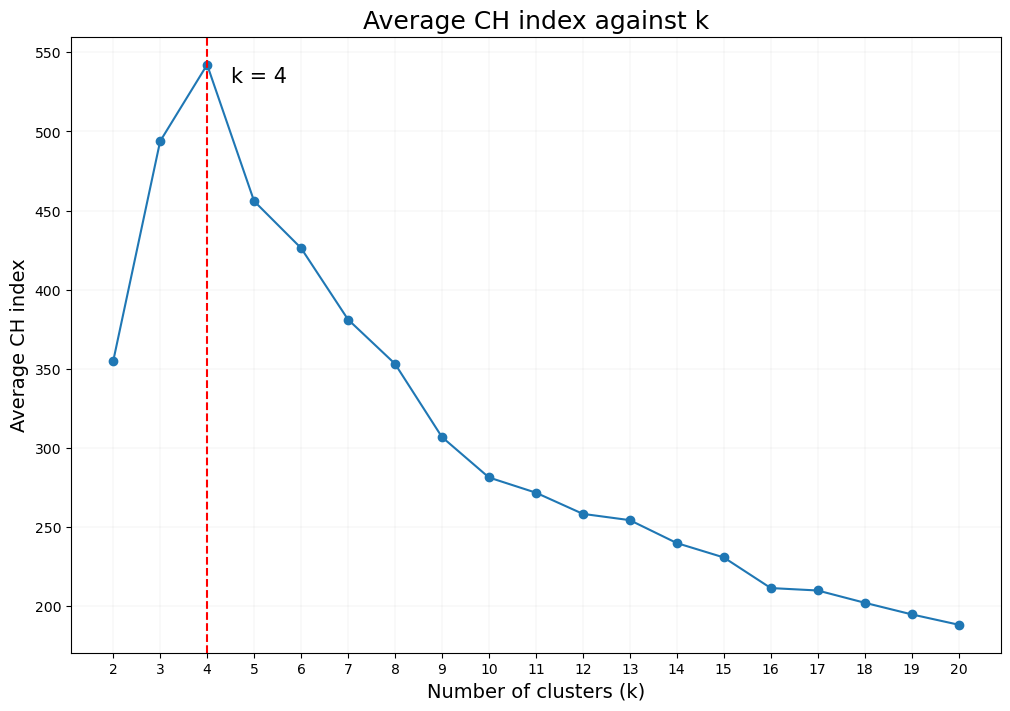

```python
# Set the size of the figure.
plt.figure(figsize=(12, 8))

# Plot the average CH index against k.
plt.plot(k_range, k_scores, marker='o')
plt.axvline(best_k, color='r', linestyle='--')
plt.annotate(
    f"k = {best_k}",
    xy=(best_k, best_k_ch_index),
    xytext=(best_k + 0.5, best_k_ch_index - 1),
    color='black',
    fontsize=15,
    ha='left',
    va='top',
)

# Customize the plot.
plt.grid(visible=True, linewidth=0.1)
plt.title('Average CH index against k', fontsize=18)
plt.xlabel('Number of clusters (k)', fontsize=14)
plt.ylabel('Average CH index', fontsize=14)
plt.xticks(k_range, fontsize=10)
plt.yticks(fontsize=10)

# Show the plot.
plt.show()
```

#### 2.1.2

Given a set of classes $C$ and a set of clusters $K$, the **homogeneity score** is given by

$$ \text{Homogeneity score} = 1 - \frac{H(C|K)}{H(C)} $$

Here, the $H$ functions are the entropies defined as follows:

$$ H(C|K) = - \sum_{k = 1}^{|K|} \sum_{c = 1}^{|C|} \frac{a_{ck}}{N} \log \left( \frac{a_{ck}}{\sum_{c = 1}^{|C|} a_{ck}} \right) $$$$ H(C) = - \sum_{c = 1}^{|C|} \frac{\sum_{k = 1}^{|K|} a_{ck}}{N} \log \left( \frac{\sum_{k = 1}^{|K|} a_{ck}}{N} \right) $$

where

- $N$ is the total number of data points
- $a_{ck}$ represents the number of samples that belong to class $c$ and are assigned to cluster $k$.

We start by computing the contigency matrix, which is a $c \times k$ matrix given by $(A)_{ck} = a_{ck}$.

```python
def contingency_matrix(classes, clusters):
    """
    Computes the contingency matrix for the given clusters and classes.

    Parameters
    ----------
    :param classes: {np.ndarray} of shape (num_data_points,) --
        Array of true classes.
    :param clusters: {np.ndarray} of shape (num_data_points,) --
        Array of assigned clusters.

    Returns:
    ----------
    :rtype: {np.ndarray} of shape (num_labels, num_clusters)
    :return: The contingency matrix.
    """

    # Get the number of data points.
    num_data_points = clusters.shape[0]
    assert num_data_points == classes.shape[0], "Number of data points must be equal. "

    # Remove duplicates.
    unique_classes = np.unique(classes)
    unique_clusters = np.unique(clusters)

    # Get the number of unique classes and clusters.
    num_classes = unique_classes.shape[0]
    num_clusters = unique_clusters.shape[0]

    # Initialise the contingency table.
    contingency_table = np.zeros((num_classes, num_clusters))

    # Compute the contingency table.
    for (c, label) in enumerate(unique_classes):
        mask_label = (classes == label)
        for (k, cluster) in enumerate(unique_clusters):
            mask_cluster = (clusters == cluster)
            contingency_table[c, k] = np.sum(mask_label & mask_cluster)

    return contingency_table
```

We now implement the `homogeneity_score()`.

```python
def homogeneity_score(classes, clusters):
    """
    Computes the homogeneity score for the given clusters and classes.

    Parameters
    ----------
    :param classes: {np.ndarray} of shape (num_data_points,) --
        Array of true classes.
    :param clusters: {np.ndarray} of shape (num_data_points,) --
        Array of assigned clusters.

    Returns:
    ----------
    :rtype: {scalar}
    :return: The homogeneity score.
    """

    N = clusters.shape[0]  # number of data points
    num_classes = np.unique(classes).shape[0]
    num_clusters = np.unique(clusters).shape[0]

    # Compute the contingency table.
    contingency_table = contingency_matrix(classes, clusters)

    num_points_in_class = np.sum(contingency_table, axis=1)
    num_points_in_labels = np.sum(contingency_table, axis=0)

    # Compute the H(C|K) score.
    hck_score = 0
    for k in range(num_clusters):
        a_k = num_points_in_labels[k]
        for c in range(num_classes):
            a_ck = contingency_table[c, k]
            # Skip if there are no points in this cluster.
            if a_ck == 0:
                continue
            hck_score -= (a_ck / N) * np.log(a_ck / a_k)

    # Compute the H(C) score.
    hc_score = 0
    for c in range(num_classes):
        a_c = num_points_in_class[c]  # number of points in class c
        p_c = a_c / N  # percentage of points in class c
        hc_score -= p_c * np.log(p_c)

    # Compute the homogeneity score.
    homogeneity_score = 1 - hck_score / hc_score

    return homogeneity_score
```

We now look at the homogeneity score of our clustering of the samples we obtained in 2.1.1 using the optimal `k`.

```python
# Compute the homogeneity score.
hom_score = homogeneity_score(gene_type, labels)

# Print the homogeneity score.
print("Homogeneity score:", hom_score)
```

```
Homogeneity score: 0.6653242487126452
```

The homogeneity score is $\approx 0.665$. Homogeneity refers to the degree to which each cluster contains only data points that belong to a single class or group.

This indicates that the algorithm has been successful to some extent in separating the data points into clusters that are homogeneous with respect to the class labels. However, there is still room for improvement, as some data points in each cluster may not belong to the same class or group.

The optimal $k$ that we got is $4$, while the number of tumour types is $5$. This suggests that the class labels may not be perfectly separable in the space spanned by the descriptors (i.e. there is some overlap between the tumour types in terms of gene expression levels).

All things considered, if we want to improve the clustering, we could try the following:

1. Change our implementation of K-Means:
   - We could use a different distance metric.
   - We could use a different initialisation strategy.
   - We could use a different stopping criterion.
2. Use a different clustering algorithm (K-means may not necessarily be the best clustering algorithm for this task).

### 2.2 Graph-based analysis (20 marks)

We now reimport the packages, the data and the implementation of K-Means.

```python
import numpy as np
import pandas as pd
import matplotlib.pyplot as plt

from scipy.linalg import eigh
from scipy.sparse import linalg
from scipy.stats import multivariate_normal


# Load the data.
gene_expression_data = pd.read_csv('gene_expression_data.csv')

# Get the descriptors and target data.
gene_features = gene_expression_data.drop(columns=['Type'])
gene_type = gene_expression_data['Type']

# Convert the data to a numpy array.
gene_features = gene_features.to_numpy()
gene_type = gene_type.to_numpy()


class KMeans:

    def __init__(
            self, k,
            max_iter=100,
            seed=None,
    ):
        """
        Initializes the KMeans object.

        Parameters
        ----------
        :param k: {int} --
            Number of clusters to be found.
        :param max_iter: {int}, optional, default=100 --
            Maximum number of iterations to be performed.
        :param seed: {int}, optional, default=None --
            Seed for random number generator.
        """

        self.k = k
        self.max_iter = max_iter
        self.seed = seed

    def fit_predict(self, X):
        """
        Performs k-means clustering on the data.

        Parameters
        ----------
        :param X: {np.ndarray} of shape (num_data_points, num_features) --
            Array of data points.

        Returns:
        ----------
        :rtype: {np.ndarray} of shape (num_data_points, )
        :return: Array of cluster assignments.
        """

        num_observations = X.shape[0]

        # Initialise centroids.
        centroids = self._k_clusters_init(X)

        labels = np.zeros(num_observations)  # labels of data points

        for _ in range(self.max_iter):
            new_labels = self._update_labels(X, centroids)

            # Check if the labels have changed.
            if (labels == new_labels).all():
                break
            else:
                # Update labels
                labels = new_labels
                # Update centroids.
                for i in range(self.k):
                    cluster_points = X[labels == i]
                    # If there are no points in the cluster, then keep the old centroid.
                    if cluster_points.size == 0:
                        continue
                    centroids[i] = np.mean(cluster_points, axis=0)

        # Return the labels.
        return labels

    def _k_clusters_init(self, X):
        """
        Initialises k clusters by randomly selecting k data points from the dataset.

        Parameters
        ----------
        :param X: {np.ndarray} of shape (num_data_points, num_features) --
            Array of data points.

        Returns:
        ----------
        :rtype: {np.ndarray} of shape (k, num_features)
        :return: Array of k cluster centroids.
        """

        # Initialise the random number generator.
        rng = np.random.default_rng(self.seed)

        # Randomly select k data points from the dataset.
        num_observations = X.shape[0]
        centroids_indexes = rng.choice(num_observations, size=self.k, replace=False)
        centroids = X[centroids_indexes, :]

        return centroids

    def _update_labels(self, X, centroids):
        """
        Computes the labels of the data points.

        Parameters
        ----------
        :param X: {np.ndarray} of shape (num_data_points, num_features) --
            Array of data points.
        :param centroids: {np.ndarray} of shape (k, num_features) --
            Array of k cluster centroids.

        Returns:
        ----------
        :rtype: {np.ndarray} of shape (num_data_points, )
        :return: Array of cluster assignments.
        """

        # Compute distances between data points and centroids.
        distances = np.array([np.linalg.norm(X - c, axis=1) for c in centroids])

        # Compute new labels.
        labels = np.argmin(distances, axis=0)

        return labels
```

#### 2.2.0 Functions

The function `corr_matrix()` is the matrix of connected correlations between columns in which

1. The diagonal terms are set to $0$.
2. All the terms whose absolut value is smaller than a threshold are set to $0$.

```python
def corr_matrix(data, thres=0):
    """
    Computes the correlation matrix for the given data.

    Parameters
    ----------
    :param data: {np.ndarray} of shape (num_data_points, num_features) --
        Array of data.
    :param thres: {scalar}, optional, default=0 --
        Threshold for the correlation matrix.

    Returns:
    ----------
    :rtype: {np.ndarray} of shape (num_features, num_features)
    :return: The correlation matrix.
    """

    # Compute the correlation matrix.
    corr_mat = np.corrcoef(data, rowvar=False)

    # Set the values on the diagonal to zero.
    corr_mat[np.diag_indices_from(corr_mat)] = 0

    # Set the values below the threshold to zero.
    corr_mat[corr_mat < thres] = 0

    return corr_mat
```

The `degree_centrality()` function computes the degree centrality of each node in the graph. The degree centrality of a node is given by:

$$ \text{degree centrality}(v) = \frac{\text{weighted degree}(v)}{2 \cdot \text{number of total edges}} $$

```python
def degree_centrality(adj_matrix):
    """
    Computes the degree centrality for the given adjacency matrix.

    Parameters
    ----------
    :param adj_matrix: {np.ndarray} of shape (num_nodes, num_nodes) --
        Adjacency matrix.

    Returns:
    ----------
    :rtype: {np.ndarray} of shape (num_nodes,)
    :return: The degree centrality.
    """

    # Get the weighted degree of each node (i.e. the sum of the weights of the edges connected to it).
    degree = np.sum(adj_matrix, axis=1)

    # Get the number of edges.
    num_edges = np.sum(degree) / 2

    # Get the degree centralities
    deg_centralities = degree / (2 * num_edges)

    return deg_centralities
```

The function `sym_norm_laplacian_matrix()` computes the symmetric normalised Laplacian matrix of a graph. The symmetric normalised Laplacian matrix is given by:

$$ L = I - D^{-1/2} A D^{-1/2} $$

where

1. $A$ is the adjacency matrix of the graph.
2. $D$ is the diagonal matrix of the weighted degrees (i.e. sum of the weights of the edges incident to each node).

```python
def sym_norm_laplacian_matrix(adj_matrix):
    """
    Computes the Laplacian matrix for the given adjacency matrix.

    Parameters
    ----------
    :param adj_matrix: {np.ndarray} of shape (num_nodes, num_nodes) --
        Adjacency matrix.

    Returns:
    ----------
    :rtype: {np.ndarray} of shape (num_nodes, num_nodes)
    :return: The Laplacian matrix.
    """

    num_variables = adj_matrix.shape[0]

    # Get the sum of the weights of the edges connected to each node.
    weighted_degree = np.sum(adj_matrix, axis=1)

    # Get the D^{-1/2} matrix.
    D_inv_sqrt = np.diag(1.0 / np.sqrt(weighted_degree))

    # Get the symmetric normalized Laplacian matrix.
    sym_norm_L = np.eye(num_variables) - D_inv_sqrt @ adj_matrix @ D_inv_sqrt

    # Get a symmetric L (avoiding numerical errors).
    sym_norm_L = np.triu(sym_norm_L) + np.triu(sym_norm_L, k=1).T

    return sym_norm_L
```

#### 2.2.1

Let's compute the matrix of connected correlations between the genes in our data.

```python
genes_adj_matrix = corr_matrix(gene_features, thres=0.75)
```

Now visualise the matrix as a heatmap.

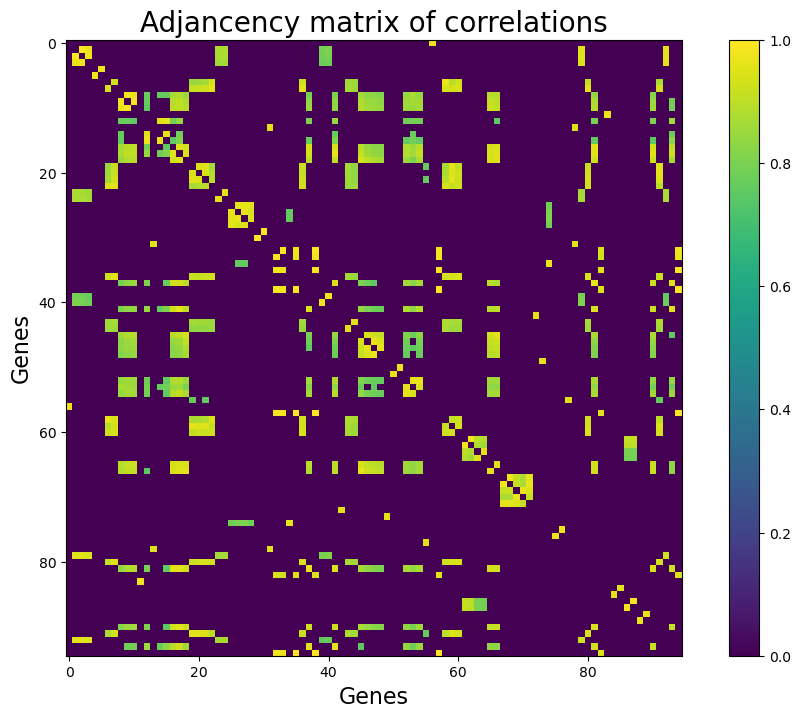

```python
# Set figure size.
plt.figure(figsize=(12, 8))

# Plot the adjancency matrix.
plt.imshow(genes_adj_matrix)

# Customize the plot.
plt.colorbar()
plt.title("Adjancency matrix of correlations", fontsize=20)
plt.xlabel("Genes", fontsize=16)
plt.ylabel("Genes", fontsize=16)
plt.xticks(fontsize=10)
plt.yticks(fontsize=10)

# Show the plot.
plt.show()
```

Here, brighter colors represent strong corrrelations and darker colors represent weak correlations. We notice that most of the correlations are weak.

#### 2.2.2

Compute the degree centrality of each node (gene) in the network, sort the genes in descending order by these values and print the index of the $5$ top ranking genes.

```python
# Compute the degree centralities.
genes_deg_centralities = degree_centrality(genes_adj_matrix)

# Sort the genes in descending order of degree centrality.
# Then get the indexes of the top 5 genes.
top_5_genes_indexes = np.argsort(genes_deg_centralities)[::-1][:5]

# Print the top 5 genes indexes.
print("Top 5 genes indexes:", top_5_genes_indexes)
```

```
Top 5 genes indexes: [17 41 16 81 90]
```

#### 2.2.3

Compute the symmetric normalised Laplacian of the graph and derive its eigenvalues and eigenvectors.

```python
# Compute the symmetric normalized Laplacian matrix of the graph.
L = sym_norm_laplacian_matrix(genes_adj_matrix)

# Get the eigenvalues and eigenvectors of the symmetric normalized Laplacian matrix.
L_eigenvalues, L_eigenvectors = eigh(L)

# Sort the eigenvalues and eigenvectors in descending order.
idx = L_eigenvalues.argsort()[::-1]
L_eigenvalues = L_eigenvalues[idx]
L_eigenvectors = L_eigenvectors[:, idx]
```

Set the very small eigenvalues to $0$.

```python
thres = 1e-14

L_eigenvalues_thres = L_eigenvalues.copy()

# Set the eigenvalues below the threshold to zero.
L_eigenvalues_thres[L_eigenvalues_thres < thres] = 0
```

Print the number $r$ of zero eigenvalues.

```python
# Get the number of zero eigenvalues.
r = np.count_nonzero(L_eigenvalues_thres == 0)

# Get the first zero index.
first_zero_index = np.where(L_eigenvalues_thres == 0)[0][0]

# Print the number of zero eigenvalues.
print("Number of zero eigenvalues:", r)
```

```
Number of zero eigenvalues: 18
```

Now we plot the spectrum of eigenvalues. On the plot, we mark the gap between eigenvalues that, upon numerical rounding, have respectively zero and non-zero values.

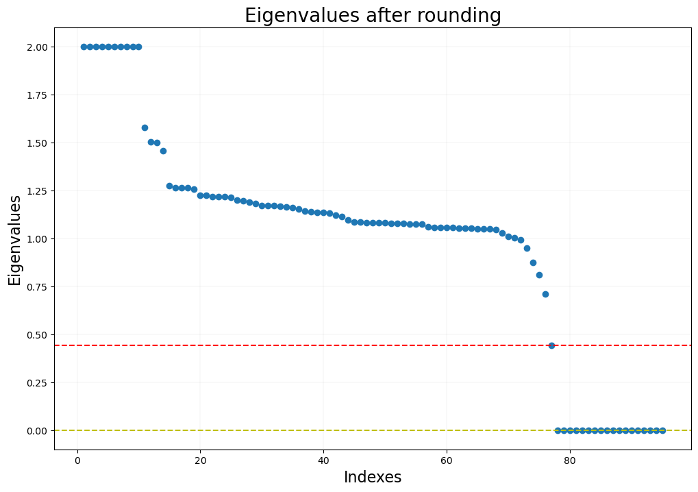

```python
# Set figure size.
plt.figure(figsize=(12, 8))

# Plot the eigenvalues.
plt.plot(
    np.arange(1, len(L_eigenvalues_thres) + 1),
    L_eigenvalues_thres,
    marker='o',
    linestyle='None',
)
plt.axhline(
    L_eigenvalues_thres[first_zero_index - 1],
    color='r',
    linestyle='--'
)
plt.axhline(
    L_eigenvalues_thres[first_zero_index],
    color='y',
    linestyle='--'
)

# Customize the plot.
plt.grid(visible=True, linewidth=0.1)
plt.title("Eigenvalues after rounding", fontsize=20)
plt.xlabel("Indexes", fontsize=16)
plt.ylabel("Eigenvalues", fontsize=16)
plt.xticks(fontsize=10)
plt.yticks(fontsize=10)

# Show the plot.
plt.show()
```

Let's see the size of the gap.

```python
# Print the value of the gap.
print(f"Value of the gap: {L_eigenvalues_thres[first_zero_index - 1]}")
```

```
Value of the gap: 0.4406743414282049
```

The number of zero eigenvalues of the symmetric normalized Laplacian of a graph is equal to the number of connected components of the graph.

Hence, in the genes graph, we have $r = 18$ connected components (hence $r = 18$ clusters of genes).

By looking at the gap between zero and non-zero eigenvalues, we see that it is around $0.44$. This suggests that the clusters are well separated from each other.

#### 2.2.4

Let $U$ be the $95 \times r$ matrix containing the $r$ eigenvectors of the symmetric normalised Laplacian corresponding to zero eigenvalues as columns.

$$ T_{ij} = \frac{U_{ij}}{\sqrt{\sum_{k = 1}^r U_{ik}^2}} $$

for all $i \in \{ 1, \ldots, 95 \}$ and $j \in \{ 1, \ldots, r \}$.

```python
# Get the U matrix.
U = L_eigenvectors[:, first_zero_index:]

# Get the T matrix.
T = np.zeros((U.shape[0], r))
for i in range(U.shape[0]):
    norm_i = np.linalg.norm(U[i, :])
    T[i, :] = U[i, :] / norm_i
```

Now let's implement a function that computer the normalized within-cluster distance. Notice that

$$ W = \frac{1}{2} \sum_{l = 1}^k \frac{1}{\lvert c_l \rvert} \sum_{i, j \in c_l} \lVert x^{(i)} - x^{(j)} \rVert^2 = \sum_{l = 1}^k \sum_{i \in c_l} \lVert x^{(i)} - m_l \rVert^2 $$

where $m_l$ is the centroid of cluster $c_l$.

```python
def within_cluster_dist(data, clusters):
    """
    Computes the normalized within-cluster distance.

    Parameters
    ----------
    :param data: {np.ndarray} of shape (num_samples, num_features) --
        The data.
    :param clusters: {np.ndarray} of shape (num_samples,) --
        The clusters.

    Returns
    ----------
    :rtype: {scalar}
    :return: The normalized within-cluster distance.
    """

    # Initialize the normalized within-cluster distance.
    distance = 0

    for cluster in np.unique(clusters):
        # Get the data points in the cluster.
        cluster_points = data[clusters == cluster]

        # If the cluster is empty, skip it.
        if cluster_points.size == 0:
            continue

        # Compute the centroid.
        cluster_centroid = np.mean(cluster_points, axis=0)

        # Update the normalized within-cluster distance.
        distance += np.sum((cluster_points - cluster_centroid) ** 2)

    return distance
```

Now we apply k-means to the matrix $T$ varying $k$. In order to set the appropiate value of $k$, we use the elbow method and the previously defined normalized within-cluster distance.

```python
def min_dist_k_means(data, k, num_iter=2000):
    """
    Computes the minimum normalized within-cluster distance
    for multiple runs of the k-means algorithm and the corresponding clusters.

    Parameters
    ----------
    :param data: {np.ndarray} of shape (num_samples, num_features) --
        The data.
    :param k: {scalar} --
        The number of clusters.
    :param num_iter: {scalar}, optional, default=1000 --
        The number of iterations.

    Returns
    ----------
    :rtype: {tuple}
    :return: A tuple containing the minimum normalized within-cluster distance and the corresponding clusters.
    """

    min_W = np.Inf
    min_labels = None

    for _ in range(num_iter):
        # Run K-means.
        clusters = KMeans(k, max_iter=100).fit_predict(data)

        # Compute the normalized within-cluster distance.
        W = within_cluster_dist(data, clusters)

        # Update the minimum normalized within-cluster distance.
        if W < min_W:
            min_W = W
            min_labels = clusters

    return min_W, min_labels
```

```python
# Set the range for k.
k_range = range(1, T.shape[0] + 1)

# Compute the minimum normalized within-cluster distance for each k.
min_W_vals, min_labels = zip(*[min_dist_k_means(T, k) for k in k_range])
```

We provide an elbow plot in order to set the appropiate value of $k$.

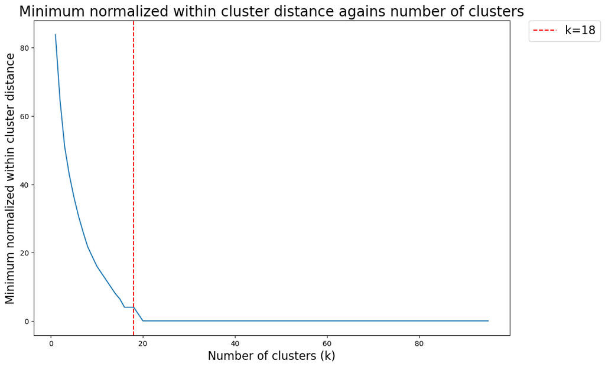

```python
# Set figure size.
plt.figure(figsize=(12, 8))

# Plot the adjancency matrix.
plt.plot(k_range, min_W_vals)
plt.axvline(18, color='r', linestyle='--', label="k=18")

# Customize the plot.
plt.title("Minimum normalized within cluster distance agains number of clusters", fontsize=20)
plt.xlabel("Number of clusters (k)", fontsize=16)
plt.ylabel("Minimum normalized within cluster distance", fontsize=16)
plt.xticks(fontsize=10)
plt.yticks(fontsize=10)
plt.legend(
    bbox_to_anchor=(1.04, 1),
    borderaxespad=0,
    loc="upper left",
    fontsize=16,
)

# Show the plot.
plt.show()
```

By looking at the plot, we see that $k = 18$ is a good candidate. Hence we set the optimal value of $k$ to $18$ and obtain the corresponding clustering.

```python
# Set the optimal value of k.
k_optim = 18

# Get the optimal k labels.
k_optim_labels = min_labels[k_optim - 1]

# Get the size of each cluster.
pd.DataFrame(
    [np.count_nonzero(k_optim_labels == i) for i in range(k_optim)],
    columns=["Size of the cluster"],
    index=[f"Cluster {i}:" for i in range(k_optim)]
)
```

|  | Size of the cluster |
| --- | --- |
| Cluster 0: | 2 |
| Cluster 1: | 5 |
| Cluster 2: | 1 |
| Cluster 3: | 2 |
| Cluster 4: | 3 |
| Cluster 5: | 2 |
| Cluster 6: | 2 |
| Cluster 7: | 3 |
| Cluster 8: | 6 |
| Cluster 9: | 23 |
| Cluster 10: | 16 |
| Cluster 11: | 2 |
| Cluster 12: | 2 |
| Cluster 13: | 9 |
| Cluster 14: | 4 |
| Cluster 15: | 7 |
| Cluster 16: | 2 |
| Cluster 17: | 4 |

Let's also print the number of elements in the biggest cluster.

```python
# Get the number of elements of the biggest cluster.
num_elem_biggest_cluster = np.max([np.count_nonzero(k_optim_labels == i) for i in range(k_optim)])

# Print it.
print(f"Number of elements of the biggest cluster: {num_elem_biggest_cluster}")
```

```
Number of elements of the biggest cluster: 23
```

From our spectral analysis, we got that the number of connected components in the graph is $r = 18$. That means that, when the number of clusters is $k = 18$, the clustering could be perfect.

When we look at the clustering obtained from $k = 18$, we see that the biggest one has $23$ elements, which is quite big in comparison to the other clusters.This suggests that the genes in this cluster are close in terms of their expression levels. Because of this, we will perform some analysis on this cluster. We want to determine if this cluster is indeed a connected component of the graph.

#### 2.2.5

We consider the biggest cluster identified in 2.2.4 and use the normalised Laplacian to perform spectral partitioning and derive a binary partition of the subgraph corresponding to this cluster.

```python
# Get the indexes of the largest cluster.
cluster_index = np.argmax(np.bincount(k_optim_labels))
cluster_indexes = np.where(k_optim_labels == k_optim_labels[cluster_index])[0]

# Get the adjacency matrix of the largest cluster.
cluster_adjacency_matrix = genes_adj_matrix[cluster_indexes][:, cluster_indexes]

# Compute the normalized Laplacian matrix of the largest cluster.
cluster_L = sym_norm_laplacian_matrix(cluster_adjacency_matrix)

# Get the eigenvalues and eigenvectors of the normalized Laplacian matrix of the largest cluster.
cluster_L_eigenvalues, cluster_L_eigenvectors = eigh(cluster_L)
```

We sort the eigenvalues and eigenvectors in ascending order.

```python
# Sort the eigenvalues and eigenvectors in ascending order.
idx = cluster_L_eigenvalues.argsort()
cluster_L_eigenvalues = cluster_L_eigenvalues[idx]
cluster_L_eigenvectors = cluster_L_eigenvectors[:, idx]
```

We now do spectral partitioning. Since the eigenvalues/eigenvectors are sorted in ascending order, we now look at the eigenvector corresponding to the second eigenvalue. It is the algebraic connectivity of the graph. A small value means that there exists a bipartition with low cost. On the other hand, a large value means that the graph is well connected (there is no good bipartition of the graph).

```python
# Get the algebraic connectivity of the largest cluster.
cluster_algebraic_connectivity = cluster_L_eigenvalues[1]

# Print it.
print(f"The algebraic connectivity of the largest cluster is {cluster_algebraic_connectivity}.")
```

```
The algebraic connectivity of the largest cluster is 0.7098248164224781.
```

Since the algebraic connectivity is relatively small, we expect a fairly good binary partition.

```python
# Get the second eigenvector.
cluster_second_eigenvector = cluster_L_eigenvectors[:, 1]

# By binarizing the positive and negative eigenvector values, we get a partition.
spectral_partition = cluster_second_eigenvector
spectral_partition[spectral_partition < 0] = 0
spectral_partition[spectral_partition > 0] = 1
```

Now every point has a label $0$ or $1$. We now shuffle the adjacency matrix of the subgraph corresponding to the biggest cluster such that the first elements have label $0$ and the last elements have label $1$.

```python
# Get the indexes of the two clusters.
first_subset_indexes = np.where(spectral_partition == 0)[0]
second_subset_indexes = np.where(spectral_partition == 1)[0]
# Concatenate the indexes of the two clusters.
spectral_partition_indexes = np.concatenate((first_subset_indexes, second_subset_indexes))

# Get the adjacency matrix of the two clusters.
spectral_partition_adj_matrix = cluster_adjacency_matrix[spectral_partition_indexes][:, spectral_partition_indexes]
```

We now make a set of plots to visualise the magnitude of the network links within each partition and across the two partitions.

```python
# Get the number of zeros in the adjacency matrix of the two clusters.
num_zeros = len(first_subset_indexes)
```

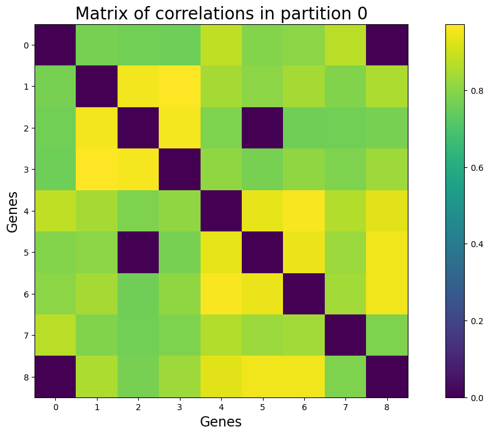

```python
# Set figure size.
plt.figure(figsize=(16, 8))

# Plot the matrix of correlations.
plt.imshow(spectral_partition_adj_matrix[0: num_zeros, 0: num_zeros])

# Customize the plot.
plt.title('Matrix of correlations in partition 0', fontsize=20)
plt.xlabel('Genes', fontsize=16)
plt.ylabel('Genes', fontsize=16)
plt.xticks(fontsize=10)
plt.yticks(fontsize=10)
plt.colorbar()

# Show the plot.
plt.show()
```

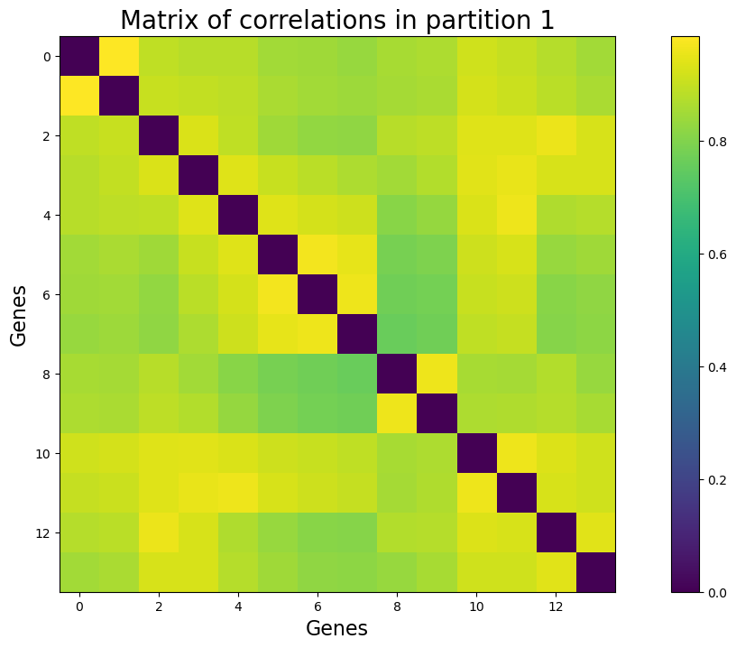

```python
# Set figure size.
plt.figure(figsize=(16, 8))

# Plot the matrix of correlations.
plt.imshow(spectral_partition_adj_matrix[num_zeros:, num_zeros:])

# Customize the plot.
plt.title('Matrix of correlations in partition 1', fontsize=20)
plt.xlabel('Genes', fontsize=16)
plt.ylabel('Genes', fontsize=16)
plt.xticks(fontsize=10)
plt.yticks(fontsize=10)
plt.colorbar()

# Show the plot.
plt.show()
```

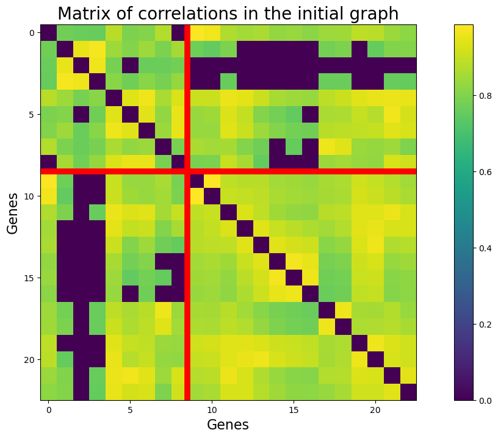

```python
# Set figure size.
plt.figure(figsize=(16, 8))

# Plot the matrix of correlations.
plt.imshow(spectral_partition_adj_matrix)
plt.axvline(num_zeros - 0.5, color='r', linewidth=7)
plt.axhline(num_zeros - 0.5, color='r', linewidth=7)

# Customize the plot.
plt.title('Matrix of correlations in the initial graph', fontsize=20)
plt.xlabel('Genes', fontsize=16)
plt.ylabel('Genes', fontsize=16)
plt.xticks(fontsize=10)
plt.yticks(fontsize=10)
plt.colorbar()

# Show the plot.
plt.show()
```

In all heatmaps, we have that the diagonal terms are $0$. That is because there is no edge between a node and itself.

For partition $0$, we see that most of the connections are pretty high. This means that the nodes in this partition are pretty well connected and there is high correlation between the genes in this partition.

For partition $1$, the connectivity is even stronger. This means that the nodes in this partition are even more well connected and there is even higher correlation between the genes in this partition.

By looking at the whole graph, we see that, although there is high connectivity and correlation between the genes in each partition, there is a lower connectivity and correlation between the two partitions. This is as expected, as the algebraic connectivity that we got before is $\approx 0.7$, which is relatively small (this suggested that we would get a fairly good partition).

#### 2.2.6

Consider the subgraph from 2.2.5. We compute the degree centrality of the nodes in this subgraph and print the index of $5$ top-ranking ones.

```python
# Compute the degree centralities.
cluster_deg_centralities = degree_centrality(cluster_adjacency_matrix)

# Sort the genes in descending order of degree centrality.
# Then get the indexes of the top 5 genes.
top_5_indexes_cluster = np.argsort(cluster_deg_centralities)[::-1][:5]

# Get the indexes in the original adjancency matrix.
top_5_indexes_graph = cluster_indexes[top_5_indexes_cluster]

# Print the top 5 genes indexes.
space = "  "
print(
    "We're now looking at the top 5 genes in the largest cluster.\n",
    f"  - indices in the adjacency matrix of the cluster: {top_5_indexes_cluster}\n",
    f"  - indices in the adjacency matrix of the graph: {top_5_indexes_graph}\n",
)
```

```
We're now looking at the top 5 genes in the largest cluster.
   - indices in the adjacency matrix of the cluster: [ 7 10  6 20 21]
   - indices in the adjacency matrix of the graph: [17 41 16 81 90]
```

Notice that the top 5 genes in the largest cluster are also the top 5 genes in the initial graph!

While this is possible given that we considered the largest cluster, it is not always the case.

Let's look at the degree centrality values in both original graph and in the cluster.

```python
# Get the degree of the 5 top genes in the original graph.
top_5_deg_centralities = np.sort(genes_deg_centralities[top_5_genes_indexes])[::-1][:5]

# Get the degree of the 5 top genes in the cluster.
cluster_top_5_deg_centralities = np.sort(cluster_deg_centralities[top_5_indexes_cluster])[::-1][:5]

print(
    "The degree centralities of the 5 top genes in the original graph are:",
    f"\n{top_5_deg_centralities}",
    "\nThe degree centralities of the 5 top genes in the cluster are:",
    f"\n{cluster_top_5_deg_centralities}",
)
```

```
The degree centralities of the 5 top genes in the original graph are:
[0.02687344 0.02593545 0.02537837 0.02523066 0.02487023]
The degree centralities of the 5 top genes in the cluster are:
[0.05289032 0.05104425 0.04994785 0.04965714 0.04894775]
```

By having a closer look, we see that they seem to be related somehow.Let's print the ratios of degree centrality values in the cluster to degree centrality values in the initial graph.

$$ \frac{\text{degree centrality in the cluster}}{\text{degree centrality in the original graph}} $$

```python
# Print the ratio of the degree centralities of the 5 top genes
# in the cluster and in the original graph.
print(
    "The ratios of degree centrality values in the cluster to degree centrality values in the initial graph are:",
    f"\n{cluster_top_5_deg_centralities / top_5_deg_centralities}",
)
```

```
The ratios of degree centrality values in the cluster to degree centrality values in the initial graph are:
[1.96812659 1.96812659 1.96812659 1.96812659 1.96812659]
```

The top 5 genes in the largest cluster are also the top 5 genes in the initial graph. We notice that they all have the same ratio, which is really close to $2$. This indicates that the biggest cluster is actually a connected component of the original graph.

Since the top $5$ genes in the cluster are also the top $5$ genes in the original graph and they have the same $\frac{\text{degree centrality in the cluster}}{\text{degree centrality in the original graph}}$ ratio, we may conclude that the subgraph may have a well-defined structure that contains important information about the genes. The subgraph may be more important than the original graph.

This is in line with what we saw before at 2.2.4: It might be better to restrict the analysis of the genes to the biggest cluster ($23$ genes in total) rather than analysing the whole graph (which has $95$ genes).

*Note.* Before starting the analysis, we should have asked ourselves if the value of the threshold is too big or too small. Maybe choosing a smaller threshold would gives us more information about the genes and the connected components, obtaining a better clustering.